# cb_challenge12

```python
'''Few Key Points:

1. Fiscal Year: The fiscal year is a one-year period used for financial reporting and budgeting, starting on April 1st and ending on March 31st of the following year in India.

2. Penetration Rate: This metric represents the percentage of total vehicles that are electric within a specific region or category. It is calculated as:
		Penetration Rate =  (Electric Vehicles Sold / Total Vehicles Sold) * 100
   This indicates the adoption level of electric vehicles.

3. Compound Annual Growth Rate (CAGR): CAGR measures the mean annual growth rate over a specified period longer than one year. It is calculated as:
		CAGR = [(Ending Value / Beginning Value) ** 1/n] -1 '''
```

Basic data cleaning done in Excel itself

```python
import pandas as pd
```

```python
import numpy as np
```

```python
import seaborn as sns
```

```python
import matplotlib.pyplot as plt
```

```python
df1=pd.read_csv(r"C:\Users\adian\Downloads\study\python\EV project\datasets\dim_date.csv")
```

```python
df2=pd.read_csv(r"C:\Users\adian\Downloads\study\python\EV project\datasets\electric_vehicle_sales_by_makers.csv")
```

```python
df3=pd.read_csv(r"C:\Users\adian\Downloads\study\python\EV project\datasets\electric_vehicle_sales_by_state.csv")
```

```python
# knowing the datasets
```

```python
df1.shape
```

```
(36, 4)
```

```python
df2.shape
```

```
(816, 4)
```

```python
df3.shape
```

```
(2445, 5)
```

```python
df1.info()
```

```
<class 'pandas.core.frame.DataFrame'>
RangeIndex: 36 entries, 0 to 35
Data columns (total 4 columns):
 #   Column       Non-Null Count  Dtype
---  ------       --------------  -----
 0   date         36 non-null     object
 1   fiscal_year  36 non-null     int64
 2   quarter      36 non-null     object
 3   FY_QTR       36 non-null     object
dtypes: int64(1), object(3)
memory usage: 1.2+ KB
```

```python
df2.info()
```

```
<class 'pandas.core.frame.DataFrame'>
RangeIndex: 816 entries, 0 to 815
Data columns (total 4 columns):
 #   Column                  Non-Null Count  Dtype
---  ------                  --------------  -----
 0   date                    816 non-null    object
 1   vehicle_category        816 non-null    object
 2   maker                   816 non-null    object
 3   electric_vehicles_sold  816 non-null    int64
dtypes: int64(1), object(3)
memory usage: 25.6+ KB
```

```python
df3.info()
```

```
<class 'pandas.core.frame.DataFrame'>
RangeIndex: 2445 entries, 0 to 2444
Data columns (total 5 columns):
 #   Column                  Non-Null Count  Dtype
---  ------                  --------------  -----
 0   date                    2445 non-null   object
 1   state                   2445 non-null   object
 2   vehicle_category        2445 non-null   object
 3   electric_vehicles_sold  2445 non-null   int64
 4   total_vehicles_sold     2445 non-null   int64
dtypes: int64(2), object(3)
memory usage: 95.6+ KB
```

```python
df1.head()
```

[output not shown]

```python
df1.head().to_csv('outputdf1.csv')
```

```python
df2.tail(5)
```

|  | date | vehicle_category | maker | electric_vehicles_sold |
| --- | --- | --- | --- | --- |
| 811 | 2024-03-01 | 2-Wheelers | BGAUSS | 3070 |
| 812 | 2024-03-01 | 2-Wheelers | BATTRE ELECTRIC | 625 |
| 813 | 2024-03-01 | 2-Wheelers | KINETIC GREEN | 3915 |
| 814 | 2024-03-01 | 2-Wheelers | REVOLT | 585 |
| 815 | 2024-03-01 | 2-Wheelers | OTHERS | 10579 |

```python
df2.tail().to_csv('outputdf2.csv')
```

```python
df3.tail()
```

|  | date | state | vehicle_category | electric_vehicles_sold | total_vehicles_sold |
| --- | --- | --- | --- | --- | --- |
| 2440 | 2024-03-01 | Mizoram | 2-Wheelers | 58 | 1932 |
| 2441 | 2024-03-01 | DNH and DD | 2-Wheelers | 25 | 780 |
| 2442 | 2024-03-01 | Manipur | 2-Wheelers | 13 | 1394 |
| 2443 | 2024-03-01 | Andaman & Nicobar Island | 2-Wheelers | 2 | 447 |
| 2444 | 2024-03-01 | Nagaland | 2-Wheelers | 2 | 1180 |

```python
df3.tail().to_csv('outputdf3.csv')
```

```python
# find null values if any
df1.isnull().sum()
```

```
date           0
fiscal_year    0
quarter        0
dtype: int64
```

```python
df2.isnull().sum()
```

```
date                      0
vehicle_category          0
maker                     0
electric_vehicles_sold    0
dtype: int64
```

```python
df3.isnull().sum()
```

```
date                      0
state                     0
vehicle_category          0
electric_vehicles_sold    0
total_vehicles_sold       0
dtype: int64
```

```python
# finding out outliers
```

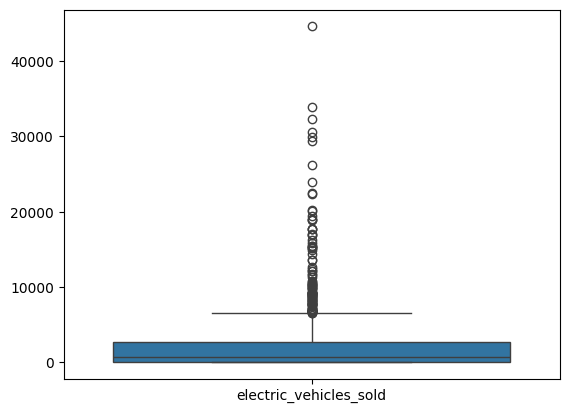

```python
sns.boxplot(data=df2)
plt.show()
```

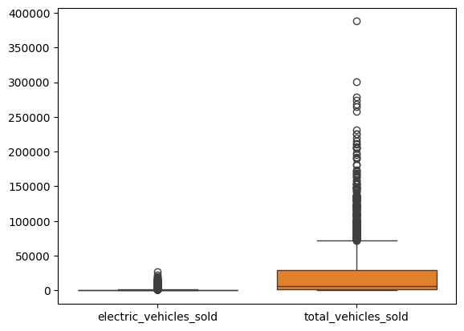

```python
sns.boxplot(data=df3)
plt.show()
```

convert the date column to datetime format for date comparisions

```python
df2['date']=pd.to_datetime(df2['date'])
df3['date']=pd.to_datetime(df2['date'])
df1['date']=pd.to_datetime(df2['date'])
```

```python
df1['date'].min()
```

```
Timestamp('2021-04-01 00:00:00')
```

```python
df2['date'].min()
```

```
Timestamp('2021-04-01 00:00:00')
```

```python
df3['date'].min()
```

```
Timestamp('2021-04-01 00:00:00')
```

```python
df1['date'].max()
```

```
Timestamp('2022-06-01 00:00:00')
```

```python
df2['date'].max()
```

```
Timestamp('2024-03-01 00:00:00')
```

```python
df3['date'].max()
```

```
Timestamp('2024-03-01 00:00:00')
```

we have dates from '2021-04-01' to '2024-03-01'.so our financial years are- FY2022='2021-04-01' to '2022-03-31' FY2023='2022-04-01' to '2023-03-31' FY2024='2023-04-01' to '2024-03-31'

```python
                                            #preliminary research questions
```

```python
#1.List the top 3 and bottom 3 makers for the fiscal years 2023 and 2024 in terms of the number of 2-wheelers sold.
```

```python
df2["vehicle_category"].value_counts()
```

```
vehicle_category
2-Wheelers    456
4-Wheelers    360
Name: count, dtype: int64
```

```python
df2wh_23 = df2[(df2["vehicle_category"] == "2-Wheelers") & (df2['date'] > '2022-03-31') & (df2['date'] < '2023-04-01')]
df2wh_24 = df2[(df2["vehicle_category"] == "2-Wheelers") & (df2['date'] > '2023-03-31') & (df2['date'] < '2024-04-01')]
```

```python
df2wh['vehicle_category'].value_counts()
```

```
vehicle_category
2-Wheelers    156
Name: count, dtype: int64
```

```python
df2wh_23
```

|  | date | vehicle_category | maker | electric_vehicles_sold |
| --- | --- | --- | --- | --- |
| 1 | 2022-04-01 | 2-Wheelers | OKAYA EV | 0 |
| 380 | 2022-04-01 | 2-Wheelers | OLA ELECTRIC | 13601 |
| 381 | 2022-04-01 | 2-Wheelers | OKINAWA | 11341 |
| 382 | 2022-04-01 | 2-Wheelers | HERO ELECTRIC | 6803 |
| 383 | 2022-04-01 | 2-Wheelers | AMPERE | 6864 |
| ... | ... | ... | ... | ... |
| 798 | 2023-03-01 | 2-Wheelers | REVOLT | 1140 |
| 799 | 2023-03-01 | 2-Wheelers | PURE EV | 584 |
| 800 | 2023-03-01 | 2-Wheelers | BEING | 446 |
| 801 | 2023-03-01 | 2-Wheelers | JITENDRA | 350 |
| 802 | 2023-03-01 | 2-Wheelers | OTHERS | 5089 |

156 rows × 4 columns

```python
df2wh_24
```

|  | date | vehicle_category | maker | electric_vehicles_sold |
| --- | --- | --- | --- | --- |
| 392 | 2023-04-01 | 2-Wheelers | OLA ELECTRIC | 22548 |
| 393 | 2023-04-01 | 2-Wheelers | TVS | 8654 |
| 394 | 2023-04-01 | 2-Wheelers | ATHER | 7707 |
| 395 | 2023-04-01 | 2-Wheelers | BAJAJ | 4043 |
| 396 | 2023-04-01 | 2-Wheelers | AMPERE | 8767 |
| ... | ... | ... | ... | ... |
| 811 | 2024-03-01 | 2-Wheelers | BGAUSS | 3070 |
| 812 | 2024-03-01 | 2-Wheelers | BATTRE ELECTRIC | 625 |
| 813 | 2024-03-01 | 2-Wheelers | KINETIC GREEN | 3915 |
| 814 | 2024-03-01 | 2-Wheelers | REVOLT | 585 |
| 815 | 2024-03-01 | 2-Wheelers | OTHERS | 10579 |

156 rows × 4 columns

```python
total_sales_2023 = df2wh_23.groupby("maker")["electric_vehicles_sold"].sum().sort_values(ascending=False)
```

```python
total_sales_2023
```

```
maker
OLA ELECTRIC     152583
OKINAWA           96945
HERO ELECTRIC     88993
AMPERE            87376
TVS               82093
ATHER             76921
OTHERS            52953
BAJAJ             32797
OKAYA EV          13172
REVOLT            12933
PURE EV           11556
BEING             11018
JITENDRA           8563
Name: electric_vehicles_sold, dtype: int64
```

```python
top3_2023=total_sales_2023.head(3)
bottom3_2023=total_sales_2023.tail(3)
```

```python
top3_2023
```

```
maker
OLA ELECTRIC     152583
OKINAWA           96945
HERO ELECTRIC     88993
Name: electric_vehicles_sold, dtype: int64
```

```python
bottom3_2023
```

```
maker
PURE EV     11556
BEING       11018
JITENDRA     8563
Name: electric_vehicles_sold, dtype: int64
```

```python
total_sales_2024 = df2wh_24.groupby("maker")["electric_vehicles_sold"].sum().sort_values(ascending=False)
```

```python
top3_2024=total_sales_2024.head(3)
bottom3_2024=total_sales_2024.tail(3)
```

```python
top3_2024
```

```
maker
OLA ELECTRIC    322489
TVS             180743
ATHER           107552
Name: electric_vehicles_sold, dtype: int64
```

```python
bottom3_2024
```

```
maker
KINETIC GREEN      9585
REVOLT             7254
BATTRE ELECTRIC    4841
Name: electric_vehicles_sold, dtype: int64
```

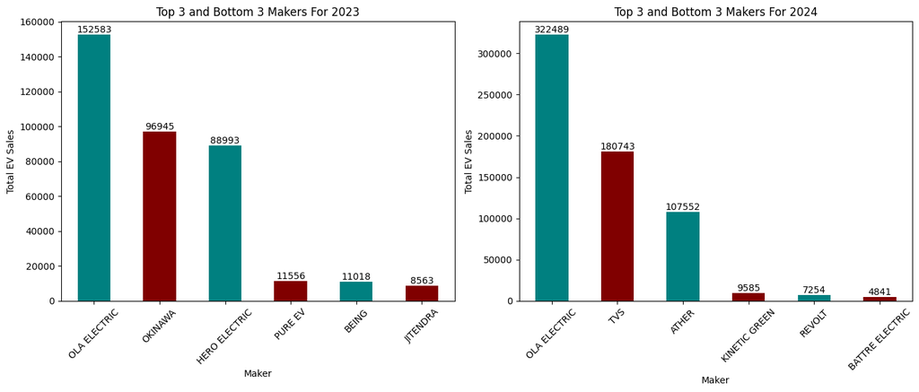

```python
# Create subplots with 1 row and 2 columns
fig, axs = plt.subplots(1, 2, figsize=(14, 6))

# First plot for 2023 data
combined_2023 = pd.concat([top3_2023, bottom3_2023])
combined_2023.plot(kind='bar', color=['teal', 'maroon'], ax=axs[0])
for index, value in enumerate(combined_2023):
    axs[0].text(index, value, str(value), ha='center', va='bottom', fontsize=10)
axs[0].set_title('Top 3 and Bottom 3 Makers For 2023')
axs[0].set_xlabel('Maker')
axs[0].set_ylabel('Total EV Sales')
axs[0].set_xticks(range(len(combined_2023)))
axs[0].set_xticklabels(combined_2023.index, rotation=45)

# Second plot for 2024 data
combined_2024 = pd.concat([top3_2024, bottom3_2024])
combined_2024.plot(kind='bar', color=['teal', 'maroon'], ax=axs[1])
for index, value in enumerate(combined_2024):
    axs[1].text(index, value, str(value), ha='center', va='bottom', fontsize=10)
axs[1].set_title('Top 3 and Bottom 3 Makers For 2024')
axs[1].set_xlabel('Maker')
axs[1].set_ylabel('Total EV Sales')
axs[1].set_xticks(range(len(combined_2024)))
axs[1].set_xticklabels(combined_2024.index, rotation=45)

# Adjust layout for better spacing
plt.tight_layout()

# Show the plot
plt.show()
```

```python
#2.Identify the top 5 states with the highest penetration rate in 2-wheeler and 4-wheeler EV sales in FY 2024.
```

```python
df3.head()
```

|  | date | state | vehicle_category | electric_vehicles_sold | total_vehicles_sold |
| --- | --- | --- | --- | --- | --- |
| 0 | 2021-04-01 | Sikkim | 2-Wheelers | 0 | 398 |
| 1 | 2022-04-01 | Sikkim | 4-Wheelers | 0 | 361 |
| 2 | 2021-05-01 | Sikkim | 2-Wheelers | 0 | 113 |
| 3 | 2021-06-01 | Sikkim | 4-Wheelers | 0 | 98 |
| 4 | 2021-07-01 | Sikkim | 2-Wheelers | 0 | 229 |

```python
df3['date']=pd.to_datetime(df3['date'])
```

```python
fy24_df3=df3[(df3['date']>'2023-03-31') & (df3['date']<'2024-04-01')]
```

```python
fy24_df3_2wh=fy24_df3[fy24_df3['vehicle_category']=='2-Wheelers']
fy24_df3_4wh=fy24_df3[fy24_df3['vehicle_category']=='4-Wheelers']
```

```python
a2=fy24_df3_2wh.groupby('state')[['electric_vehicles_sold','total_vehicles_sold']].sum()
a4=fy24_df3_4wh.groupby('state')[['electric_vehicles_sold','total_vehicles_sold']].sum()
```

```python
a2['penetration_rate']=100*(a2['electric_vehicles_sold']/a2['total_vehicles_sold'])
```

```python
a4['penetration_rate']=100*(a4['electric_vehicles_sold']/a4['total_vehicles_sold'])
```

```python
top5_2wh=a2.sort_values(by="penetration_rate",ascending=False).head()
top5_4wh=a4.sort_values(by="penetration_rate",ascending=False).head()
```

```python
top5_2wh
```

| state | electric_vehicles_sold | total_vehicles_sold | penetration_rate |
| --- | --- | --- | --- |
| DNH and DD | 1 | 657 | 0.152207 |
| Ladakh | 1 | 1057 | 0.094607 |
| Manipur | 1 | 2049 | 0.048804 |
| Nagaland | 3 | 7418 | 0.040442 |
| Andaman & Nicobar Island | 1 | 3714 | 0.026925 |

```python
top5_4wh
```

| state | electric_vehicles_sold | total_vehicles_sold | penetration_rate |
| --- | --- | --- | --- |
| Maharashtra | 4043 | 154835 | 2.611167 |
| Goa | 95 | 3841 | 2.473314 |
| Delhi | 706 | 40295 | 1.752078 |
| Kerala | 344 | 31556 | 1.090125 |
| Andaman & Nicobar Island | 12 | 1212 | 0.990099 |

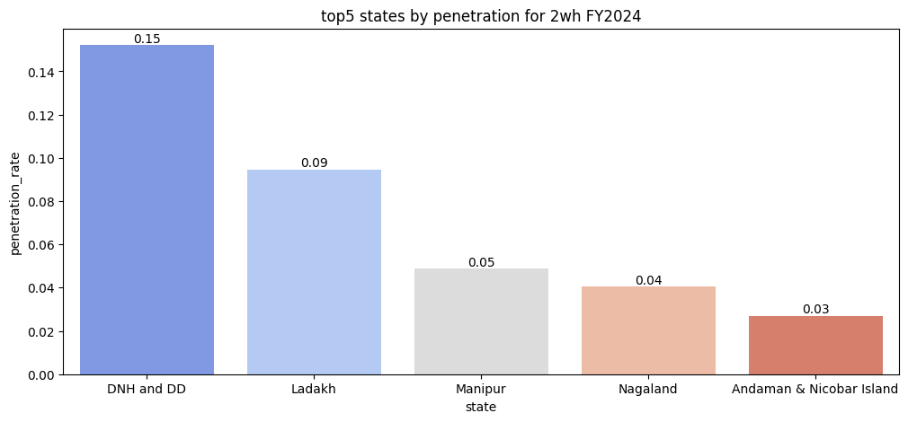

```python
#add data labels
plt.figure(figsize=(12,5))
ax=sns.barplot(x='state',y='penetration_rate',data=top5_2wh.head(5),palette='coolwarm')
for bar in ax.patches:
    ax.text(
        bar.get_x() + bar.get_width() / 2,  # X coordinate (center of the bar)
        bar.get_height(),                   # Y coordinate (height of the bar)
        '{:.2f}'.format(bar.get_height()),         # Label text (formatted value)
        ha='center', va='bottom'            # Align the text in the center horizontally and above the bar vertically
    )
plt.title('top5 states by penetration for 2wh FY2024')
plt.show()
```

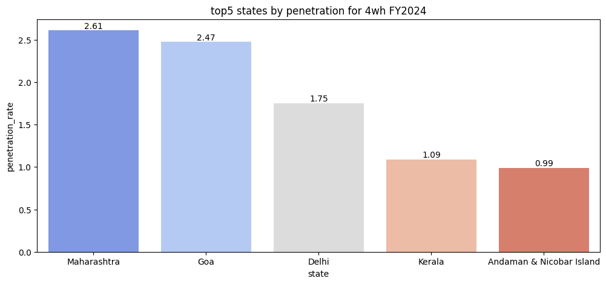

```python
#add data labels
plt.figure(figsize=(12,5))
ax=sns.barplot(x='state',y='penetration_rate',data=top5_4wh.head(5),palette='coolwarm')
for bar in ax.patches:
    ax.text(
        bar.get_x() + bar.get_width() / 2,  # X coordinate (center of the bar)
        bar.get_height(),                   # Y coordinate (height of the bar)
        '{:.2f}'.format(bar.get_height()),         # Label text (formatted value)
        ha='center', va='bottom'            # Align the text in the center horizontally and above the bar vertically
    )
plt.title('top5 states by penetration for 4wh FY2024')
plt.show()
```

```python
# 3.List the states with negative penetration (decline) in EV sales from 2022 to 2024?
```

```python
fy22_df3=df3[(df3['date']>'2021-03-31') & (df3['date']<'2022-04-01')]
```

```python
fy24_df3=df3[(df3['date']>'2023-03-31') & (df3['date']<'2024-04-01')]
```

```python
pen22=fy22_df3.groupby('state')['electric_vehicles_sold'].sum()
```

```python
pen22.sort_values(ascending=False).head(5)
```

```
state
Maharashtra    1460
Kerala          892
Delhi           732
Karnataka       576
Tamil Nadu      358
Name: electric_vehicles_sold, dtype: int64
```

```python
pen24=fy24_df3.groupby('state')['electric_vehicles_sold'].sum()
```

```python
pen24.sort_values(ascending=False).head(5)
```

```
state
Maharashtra    4043
Delhi           706
Karnataka       520
Tamil Nadu      450
Gujarat         373
Name: electric_vehicles_sold, dtype: int64
```

```python
a22=pd.DataFrame(pen22)
```

```python
a24=pd.DataFrame(pen24)
```

```python
a22
```

| state | electric_vehicles_sold |
| --- | --- |
| Andaman & Nicobar Island | 6 |
| Andhra Pradesh | 157 |
| Arunachal Pradesh | 1 |
| Assam | 1 |
| Bihar | 25 |
| Chandigarh | 35 |
| Chhattisgarh | 30 |
| DNH and DD | 4 |
| Delhi | 732 |
| Goa | 80 |
| Gujarat | 349 |
| Haryana | 46 |
| Himachal Pradesh | 1 |
| Jammu and Kashmir | 2 |
| Jharkhand | 25 |
| Karnataka | 576 |
| Kerala | 892 |
| Ladakh | 1 |
| Madhya Pradesh | 94 |
| Maharashtra | 1460 |
| Manipur | 1 |
| Meghalaya | 10 |
| Mizoram | 2 |
| Nagaland | 3 |
| Odisha | 32 |
| Puducherry | 4 |
| Punjab | 11 |
| Rajasthan | 175 |
| Sikkim | 0 |
| Tamil Nadu | 358 |
| Tripura | 1 |
| Uttar Pradesh | 54 |
| Uttarakhand | 73 |
| West Bengal | 90 |

```python
a22.rename(columns={"electric_vehicles_sold":"EV_sold_2022"},inplace=True)
```

```python
a24.rename(columns={"electric_vehicles_sold":"EV_sold_2024"},inplace=True)
```

```python
a=pd.concat([a22,a24],axis=1,join="inner")
```

```python
a['sales_growth']=a['EV_sold_2024']-a['EV_sold_2022']
```

```python
a
```

| state | EV_sold_2022 | EV_sold_2024 | sales_growth |
| --- | --- | --- | --- |
| Andaman & Nicobar Island | 6 | 13 | 7 |
| Andhra Pradesh | 157 | 188 | 31 |
| Arunachal Pradesh | 1 | 1 | 0 |
| Assam | 1 | 5 | 4 |
| Bihar | 25 | 25 | 0 |
| Chandigarh | 35 | 41 | 6 |
| Chhattisgarh | 30 | 44 | 14 |
| DNH and DD | 4 | 7 | 3 |
| Delhi | 732 | 706 | -26 |
| Goa | 80 | 95 | 15 |
| Gujarat | 349 | 373 | 24 |
| Haryana | 46 | 46 | 0 |
| Himachal Pradesh | 1 | 10 | 9 |
| Jammu and Kashmir | 2 | 9 | 7 |
| Jharkhand | 25 | 12 | -13 |
| Karnataka | 576 | 520 | -56 |
| Kerala | 892 | 344 | -548 |
| Ladakh | 1 | 1 | 0 |
| Madhya Pradesh | 94 | 113 | 19 |
| Maharashtra | 1460 | 4043 | 2583 |
| Manipur | 1 | 2 | 1 |
| Meghalaya | 10 | 4 | -6 |
| Mizoram | 2 | 1 | -1 |
| Nagaland | 3 | 4 | 1 |
| Odisha | 32 | 62 | 30 |
| Puducherry | 4 | 5 | 1 |
| Punjab | 11 | 23 | 12 |
| Rajasthan | 175 | 323 | 148 |
| Tamil Nadu | 358 | 450 | 92 |
| Tripura | 1 | 2 | 1 |
| Uttar Pradesh | 54 | 38 | -16 |
| Uttarakhand | 73 | 56 | -17 |
| West Bengal | 90 | 144 | 54 |

```python
a1=a[a['sales_growth']<0]['sales_growth'].sort_values(ascending=True)
```

```python
a1
```

```
state
Kerala          -548
Karnataka        -56
Delhi            -26
Uttarakhand      -17
Uttar Pradesh    -16
Jharkhand        -13
Meghalaya         -6
Mizoram           -1
Name: sales_growth, dtype: int64
```

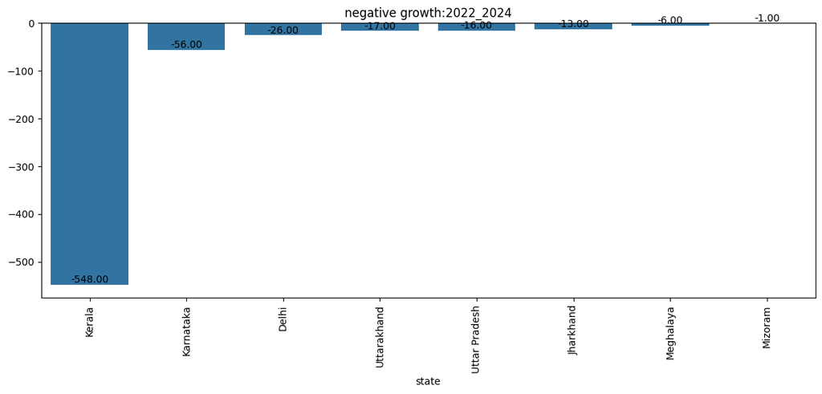

```python
plt.figure(figsize=(14,5))
ax1=sns.barplot(x=a1.index,y=a1.values)
for bar in ax1.patches:
    ax1.text(
        bar.get_x() + bar.get_width() / 2,  # X coordinate (center of the bar)
        bar.get_height(),                   # Y coordinate (height of the bar)
        '{:.2f}'.format(bar.get_height()),         # Label text (formatted value)
        ha='center', va='bottom'            # Align the text in the center horizontally and above the bar vertically
    )
plt.xticks(rotation=90)
plt.title('negative growth:2022_2024')
plt.xlabel('state')
plt.show()
```

```python
#4.What are the quarterly trends based on sales volume for the top 5 EV makers (4-wheelers) from 2022 to 2024?
```

```python
df2["vehicle_category"].value_counts()
```

```
vehicle_category
2-Wheelers    456
4-Wheelers    360
Name: count, dtype: int64
```

```python
df2.info()
```

```
<class 'pandas.core.frame.DataFrame'>
RangeIndex: 816 entries, 0 to 815
Data columns (total 4 columns):
 #   Column                  Non-Null Count  Dtype
---  ------                  --------------  -----
 0   date                    816 non-null    datetime64[ns]
 1   vehicle_category        816 non-null    object
 2   maker                   816 non-null    object
 3   electric_vehicles_sold  816 non-null    int64
dtypes: datetime64[ns](1), int64(1), object(2)
memory usage: 25.6+ KB
```

```python
IVD=df2[df2["vehicle_category"]=="4-Wheelers"]
```

```python
IVD
```

|  | date | vehicle_category | maker | electric_vehicles_sold |
| --- | --- | --- | --- | --- |
| 9 | 2021-04-01 | 4-Wheelers | BYD India | 0 |
| 10 | 2021-04-01 | 4-Wheelers | PCA Automobiles | 0 |
| 11 | 2021-04-01 | 4-Wheelers | BMW India | 0 |
| 12 | 2021-04-01 | 4-Wheelers | Volvo Auto India | 0 |
| 13 | 2021-04-01 | 4-Wheelers | KIA Motors | 0 |
| ... | ... | ... | ... | ... |
| 364 | 2024-03-01 | 4-Wheelers | PCA Automobiles | 130 |
| 365 | 2024-03-01 | 4-Wheelers | BMW India | 55 |
| 366 | 2024-03-01 | 4-Wheelers | Mercedes -Benz AG | 31 |
| 367 | 2024-03-01 | 4-Wheelers | Volvo Auto India | 39 |
| 368 | 2024-03-01 | 4-Wheelers | KIA Motors | 26 |

360 rows × 4 columns

```python
IVD['date'] = pd.to_datetime(IVD['date'])   # to compare dates
```

```python
fy22_24_IVD=IVD[(IVD['date']>'2021-03-31') & (IVD['date']<'2024-04-01')]
```

```python
fy22_24_IVD
```

|  | date | vehicle_category | maker | electric_vehicles_sold |
| --- | --- | --- | --- | --- |
| 9 | 2021-04-01 | 4-Wheelers | BYD India | 0 |
| 10 | 2021-04-01 | 4-Wheelers | PCA Automobiles | 0 |
| 11 | 2021-04-01 | 4-Wheelers | BMW India | 0 |
| 12 | 2021-04-01 | 4-Wheelers | Volvo Auto India | 0 |
| 13 | 2021-04-01 | 4-Wheelers | KIA Motors | 0 |
| ... | ... | ... | ... | ... |
| 364 | 2024-03-01 | 4-Wheelers | PCA Automobiles | 130 |
| 365 | 2024-03-01 | 4-Wheelers | BMW India | 55 |
| 366 | 2024-03-01 | 4-Wheelers | Mercedes -Benz AG | 31 |
| 367 | 2024-03-01 | 4-Wheelers | Volvo Auto India | 39 |
| 368 | 2024-03-01 | 4-Wheelers | KIA Motors | 26 |

360 rows × 4 columns

```python
Q1fy22=IVD[(IVD['date']>'2021-03-31') & (IVD['date']<'2021-06-01')]
Q2fy22=IVD[(IVD['date']>'2021-05-31') & (IVD['date']<'2021-09-01')]
Q3fy22=IVD[(IVD['date']>'2021-08-31') & (IVD['date']<'2022-01-01')]
Q4fy22=IVD[(IVD['date']>'2021-12-31') & (IVD['date']<'2022-04-01')]
```

```python
Q1fy23=IVD[(IVD['date']>'2022-03-31') & (IVD['date']<'2022-06-01')]
Q2fy23=IVD[(IVD['date']>'2022-05-31') & (IVD['date']<'2022-09-01')]
Q3fy23=IVD[(IVD['date']>'2022-08-31') & (IVD['date']<'2023-01-01')]
Q4fy23=IVD[(IVD['date']>'2022-12-31') & (IVD['date']<'2023-04-01')]
```

```python
Q1fy24=IVD[(IVD['date']>'2023-03-31') & (IVD['date']<'2023-06-01')]
Q2fy24=IVD[(IVD['date']>'2023-05-31') & (IVD['date']<'2023-09-01')]
Q3fy24=IVD[(IVD['date']>'2023-08-31') & (IVD['date']<'2024-01-01')]
Q4fy24=IVD[(IVD['date']>'2023-12-31') & (IVD['date']<'2024-04-01')]
```

```python
Top5_maker = fy22_24_IVD.groupby("maker")["electric_vehicles_sold"].sum().sort_values(ascending=False).head(5)
```

Use Top5_maker to filter and group in all quarters top5_sales_Q1fy22 = Q1fy22[Q1fy22['maker'].isin(Top5_maker.index)] Q1fy22_top5 = top5_sales_Q1fy22.groupby("maker")["electric_vehicles_sold"].sum() we can combine these two to write Q1fy22_top5 = Q1fy22[Q1fy22['maker'].isin(Top5_maker.index)].groupby("maker")["electric_vehicles_sold"].sum()

```python
Top5_maker
```

```
maker
Tata Motors            88935
Mahindra & Mahindra    41193
MG Motor               13753
BYD India               2419
Hyundai Motor           2076
Name: electric_vehicles_sold, dtype: int64
```

```python
Q1fy22_top5 = Q1fy22[Q1fy22['maker'].isin(Top5_maker.index)].groupby("maker")["electric_vehicles_sold"].sum()
Q2fy22_top5 = Q2fy22[Q2fy22['maker'].isin(Top5_maker.index)].groupby("maker")["electric_vehicles_sold"].sum()
Q3fy22_top5 = Q3fy22[Q3fy22['maker'].isin(Top5_maker.index)].groupby("maker")["electric_vehicles_sold"].sum()
Q4fy22_top5 = Q4fy22[Q4fy22['maker'].isin(Top5_maker.index)].groupby("maker")["electric_vehicles_sold"].sum()
```

```python
Q1fy23_top5 = Q1fy23[Q1fy23['maker'].isin(Top5_maker.index)].groupby("maker")["electric_vehicles_sold"].sum()
Q2fy23_top5 = Q2fy23[Q2fy23['maker'].isin(Top5_maker.index)].groupby("maker")["electric_vehicles_sold"].sum()
Q3fy23_top5 = Q3fy23[Q3fy23['maker'].isin(Top5_maker.index)].groupby("maker")["electric_vehicles_sold"].sum()
Q4fy23_top5 = Q4fy23[Q4fy23['maker'].isin(Top5_maker.index)].groupby("maker")["electric_vehicles_sold"].sum()
```

```python
Q1fy24_top5 = Q1fy24[Q1fy24['maker'].isin(Top5_maker.index)].groupby("maker")["electric_vehicles_sold"].sum()
Q2fy24_top5 = Q2fy24[Q2fy24['maker'].isin(Top5_maker.index)].groupby("maker")["electric_vehicles_sold"].sum()
Q3fy24_top5 = Q3fy24[Q3fy24['maker'].isin(Top5_maker.index)].groupby("maker")["electric_vehicles_sold"].sum()
Q4fy24_top5 = Q4fy24[Q4fy24['maker'].isin(Top5_maker.index)].groupby("maker")["electric_vehicles_sold"].sum()
```

```python
Q1fy22_top5
```

```
maker
BYD India                0
Hyundai Motor           15
MG Motor               157
Mahindra & Mahindra    249
Tata Motors            459
Name: electric_vehicles_sold, dtype: int64
```

```python
Qtr_top5_maker = pd.concat([Q1fy22_top5, Q2fy22_top5, Q3fy22_top5, Q4fy22_top5,
                            Q1fy23_top5, Q2fy23_top5, Q3fy23_top5, Q4fy23_top5,
                            Q1fy24_top5, Q2fy24_top5, Q3fy24_top5, Q4fy24_top5],
                            axis=1)
```

```python
Qtr_top5_maker.columns = ['Q1fy22', 'Q2fy22', 'Q3fy22', 'Q4fy22',
                          'Q1fy23', 'Q2fy23', 'Q3fy23', 'Q4fy23',
                          'Q1fy24', 'Q2fy24', 'Q3fy24', 'Q4fy24']
```

```python
Qtr_top5_maker
```

| maker | Q1fy22 | Q2fy22 | Q3fy22 | Q4fy22 | Q1fy23 | Q2fy23 | Q3fy23 | Q4fy23 | Q1fy24 | Q2fy24 | Q3fy24 | Q4fy24 |
| --- | --- | --- | --- | --- | --- | --- | --- | --- | --- | --- | --- | --- |
| BYD India | 0 | 0 | 1 | 32 | 45 | 101 | 151 | 623 | 266 | 309 | 491 | 400 |
| Hyundai Motor | 15 | 38 | 31 | 26 | 36 | 137 | 248 | 155 | 171 | 350 | 531 | 338 |
| MG Motor | 157 | 663 | 674 | 153 | 358 | 601 | 1372 | 946 | 616 | 2725 | 2866 | 2622 |
| Mahindra & Mahindra | 249 | 481 | 1659 | 1653 | 1233 | 2738 | 4591 | 5243 | 8337 | 6761 | 5932 | 2316 |
| Tata Motors | 459 | 1852 | 4563 | 5834 | 3506 | 6364 | 8648 | 9528 | 3576 | 10882 | 16362 | 17361 |

```python
Qtr_top5_maker.to_csv('output2.csv')
```

```python
Qtr_top5_maker_t = Qtr_top5_maker.transpose()
```

```python
Qtr_top5_maker_t
```

| maker | BYD India | Hyundai Motor | MG Motor | Mahindra & Mahindra | Tata Motors |
| --- | --- | --- | --- | --- | --- |
| Q1fy22 | 0 | 15 | 157 | 249 | 459 |
| Q2fy22 | 0 | 38 | 663 | 481 | 1852 |
| Q3fy22 | 1 | 31 | 674 | 1659 | 4563 |
| Q4fy22 | 32 | 26 | 153 | 1653 | 5834 |
| Q1fy23 | 45 | 36 | 358 | 1233 | 3506 |
| Q2fy23 | 101 | 137 | 601 | 2738 | 6364 |
| Q3fy23 | 151 | 248 | 1372 | 4591 | 8648 |
| Q4fy23 | 623 | 155 | 946 | 5243 | 9528 |
| Q1fy24 | 266 | 171 | 616 | 8337 | 3576 |
| Q2fy24 | 309 | 350 | 2725 | 6761 | 10882 |
| Q3fy24 | 491 | 531 | 2866 | 5932 | 16362 |
| Q4fy24 | 400 | 338 | 2622 | 2316 | 17361 |

```python
Qtr_top5_maker_t.to_csv('output1.csv')
```

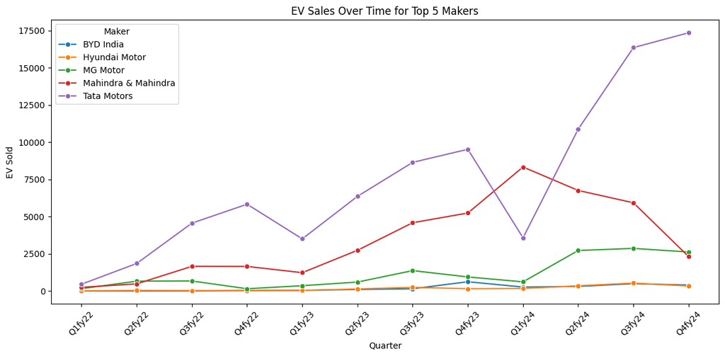

```python
plt.figure(figsize=(14, 6))

# Plot each maker's sales over the quarters
for maker in Qtr_top5_maker_t.columns:
    sns.lineplot(x=Qtr_top5_maker_t.index, y=Qtr_top5_maker_t[maker], label=maker,marker='o')

plt.title('EV Sales Over Time for Top 5 Makers')
plt.xlabel('Quarter')
plt.ylabel('EV Sold')
plt.xticks(rotation=45)  # Rotate x-axis labels for better readability
plt.legend(title='Maker')  # Add a legend title
plt.show()
```

```python
#5.How do the EV sales and penetration rates in Delhi compare to Karnataka for 2024?
```

```python
df3['date'] = pd.to_datetime(df3['date'])
df3_2024=df3[(df3['date']>'2023-03-31') & (df3['date']<'2024-04-01')]
```

```python
df3_2024_filtered = df3_2024[df3_2024['state'].isin(['Karnataka', 'Delhi'])]
result = df3_2024_filtered.groupby('state')[['electric_vehicles_sold','total_vehicles_sold']].sum()
```

```python
result
```

| state | electric_vehicles_sold | total_vehicles_sold |
| --- | --- | --- |
| Delhi | 706 | 40317 |
| Karnataka | 520 | 52955 |

```python
result['penetration_rate']=(result['electric_vehicles_sold']/result['total_vehicles_sold'])*100
```

```python
result
```

| state | electric_vehicles_sold | total_vehicles_sold | penetration_rate |
| --- | --- | --- | --- |
| Delhi | 706 | 40317 | 1.751122 |
| Karnataka | 520 | 52955 | 0.981966 |

```python
result.to_csv('output5.csv')
```

```python
data = {
    'state': ['Delhi', 'Karnataka'],
    'electric_vehicles_sold': [706,520],
    'penetration': [1.75,0.98]
}
df = pd.DataFrame(data)
```

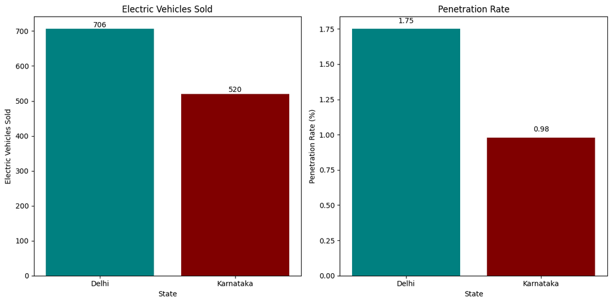

```python
plt.figure(figsize=(8, 6))


fig, axes = plt.subplots(1, 2, figsize=(12, 6))  # 1 row, 2 columns

# Plot for Electric Vehicles Sold
axes[0].bar(df['state'], df['electric_vehicles_sold'], color=['teal', 'maroon'])
axes[0].set_title('Electric Vehicles Sold')
axes[0].set_xlabel('State')
axes[0].set_ylabel('Electric Vehicles Sold')

# Add data labels to the first plot
for i, value in enumerate(df['electric_vehicles_sold']):
    axes[0].text(i, value + 1, str(value), ha='center', va='bottom', fontsize=10)

# Plot for Penetration Rate
axes[1].bar(df['state'], df['penetration'], color=['teal', 'maroon'])
axes[1].set_title('Penetration Rate')
axes[1].set_xlabel('State')
axes[1].set_ylabel('Penetration Rate (%)')

# Add data labels to the second plot
for i, value in enumerate(df['penetration']):
    axes[1].text(i, value + 0.03, str(value), ha='center', va='bottom', fontsize=10)

# Adjust layout for clarity
plt.tight_layout()

# Show the plots
plt.show()
```

```python
#6.List down the compounded annual growth rate (CAGR) in 4-wheeler units for the top 5 makers from 2022 to 2024.
#CAGR = [(Ending Value / Beginning Value) ** 1/n] -1
```

```python
IVD=df2[df2["vehicle_category"]=="4-Wheelers"]
```

```python
IVD
```

|  | date | vehicle_category | maker | electric_vehicles_sold |
| --- | --- | --- | --- | --- |
| 9 | 2021-04-01 | 4-Wheelers | BYD India | 0 |
| 10 | 2021-04-01 | 4-Wheelers | PCA Automobiles | 0 |
| 11 | 2021-04-01 | 4-Wheelers | BMW India | 0 |
| 12 | 2021-04-01 | 4-Wheelers | Volvo Auto India | 0 |
| 13 | 2021-04-01 | 4-Wheelers | KIA Motors | 0 |
| ... | ... | ... | ... | ... |
| 364 | 2024-03-01 | 4-Wheelers | PCA Automobiles | 130 |
| 365 | 2024-03-01 | 4-Wheelers | BMW India | 55 |
| 366 | 2024-03-01 | 4-Wheelers | Mercedes -Benz AG | 31 |
| 367 | 2024-03-01 | 4-Wheelers | Volvo Auto India | 39 |
| 368 | 2024-03-01 | 4-Wheelers | KIA Motors | 26 |

360 rows × 4 columns

```python
IVD['date'] = pd.to_datetime(IVD['date'])
fy22=IVD[(IVD['date']>'2021-03-31') & (IVD['date']<'2022-04-01')]
fy23=IVD[(IVD['date']>'2022-03-31') & (IVD['date']<'2023-04-01')]
fy24=IVD[(IVD['date']>'2023-03-31') & (IVD['date']<'2024-04-01')]
```

```python
fy22
```

|  | date | vehicle_category | maker | electric_vehicles_sold |
| --- | --- | --- | --- | --- |
| 9 | 2021-04-01 | 4-Wheelers | BYD India | 0 |
| 10 | 2021-04-01 | 4-Wheelers | PCA Automobiles | 0 |
| 11 | 2021-04-01 | 4-Wheelers | BMW India | 0 |
| 12 | 2021-04-01 | 4-Wheelers | Volvo Auto India | 0 |
| 13 | 2021-04-01 | 4-Wheelers | KIA Motors | 0 |
| ... | ... | ... | ... | ... |
| 344 | 2022-03-01 | 4-Wheelers | BYD India | 14 |
| 345 | 2022-03-01 | 4-Wheelers | Hyundai Motor | 14 |
| 346 | 2022-03-01 | 4-Wheelers | BMW India | 7 |
| 347 | 2022-03-01 | 4-Wheelers | Mercedes -Benz AG | 5 |
| 348 | 2022-03-01 | 4-Wheelers | Volvo Auto India | 4 |

120 rows × 4 columns

```python
fy22_24=IVD[(IVD['date']>'2021-03-31') & (IVD['date']<'2024-04-01')]
```

```python
Top5_maker = fy22_24_IVD.groupby("maker")["electric_vehicles_sold"].sum().sort_values(ascending=False).head(5)
```

```python
Top5_maker
```

```
maker
Tata Motors            88935
Mahindra & Mahindra    41193
MG Motor               13753
BYD India               2419
Hyundai Motor           2076
Name: electric_vehicles_sold, dtype: int64
```

```python
top5_22=fy22[fy22['maker'].isin(Top5_maker.index)].groupby("maker")["electric_vehicles_sold"].sum()
top5_23=fy23[fy23['maker'].isin(Top5_maker.index)].groupby("maker")["electric_vehicles_sold"].sum()
top5_24=fy24[fy24['maker'].isin(Top5_maker.index)].groupby("maker")["electric_vehicles_sold"].sum()
```

```python
top5_22
```

[output not shown]

```python
# change column name in pandas series
top5_22.name = "EV_sold_fy22"
top5_23.name=  "EV_sold_fy23"
top5_24.name = "EV_sold_fy24"
```

```python
x=pd.concat([top5_22,top5_23,top5_24],axis=1,join="inner")
```

```python
x
```

| maker | EV_sold_fy22 | EV_sold_fy23 | EV_sold_fy24 |
| --- | --- | --- | --- |
| BYD India | 33 | 920 | 1466 |
| Hyundai Motor | 110 | 576 | 1390 |
| MG Motor | 1647 | 3277 | 8829 |
| Mahindra & Mahindra | 4042 | 13805 | 23346 |
| Tata Motors | 12708 | 28046 | 48181 |

```python
x['CAGR_22_24']=x['EV_sold_fy24']/x['EV_sold_fy22']**(1/2)-1
```

```python
x
```

| maker | EV_sold_fy22 | EV_sold_fy23 | EV_sold_fy24 | CAGR_22_24 |
| --- | --- | --- | --- | --- |
| BYD India | 33 | 920 | 1466 | 254.197844 |
| Hyundai Motor | 110 | 576 | 1390 | 131.531300 |
| MG Motor | 1647 | 3277 | 8829 | 216.552820 |
| Mahindra & Mahindra | 4042 | 13805 | 23346 | 366.209854 |
| Tata Motors | 12708 | 28046 | 48181 | 426.402646 |

```python
y=x['CAGR_22_24'].sort_values(ascending=False)
```

```python
y
```

```
maker
Tata Motors            426.402646
Mahindra & Mahindra    366.209854
BYD India              254.197844
MG Motor               216.552820
Hyundai Motor          131.531300
Name: CAGR_22_24, dtype: float64
```

```python
y.to_csv('output6.csv')
```

[figure not shown]

```python
labels=x.index
sizes=y.values
colors1=['yellow','teal','orange','violet','green']
plt.figure(figsize=(7, 7))
plt.pie(sizes, labels=labels, colors=colors1, autopct='%1.1f%%', startangle=90)

# Equal aspect ratio ensures the pie chart is drawn as a circle.
plt.axis('equal')
plt.title('CAGR Distribution for Top 5 EV Makers')
plt.show()
```

```python
#7.List down the top 10 states that had the highest compounded annual growth rate (CAGR) from 2022 to 2024 in total vehicles sold.
```

```python
fy22=df3[(df3['date']>'2021-03-31') & (df3['date']<'2022-04-01')]
fy24=df3[(df3['date']>'2023-03-31') & (df3['date']<'2024-04-01')]
```

```python
fy22
```

|  | date | state | vehicle_category | electric_vehicles_sold | total_vehicles_sold |
| --- | --- | --- | --- | --- | --- |
| 0 | 2021-04-01 | Sikkim | 2-Wheelers | 0 | 398 |
| 2 | 2021-05-01 | Sikkim | 2-Wheelers | 0 | 113 |
| 3 | 2021-06-01 | Sikkim | 4-Wheelers | 0 | 98 |
| 4 | 2021-07-01 | Sikkim | 2-Wheelers | 0 | 229 |
| 5 | 2021-08-01 | Sikkim | 4-Wheelers | 0 | 244 |
| ... | ... | ... | ... | ... | ... |
| 785 | 2022-03-01 | Uttar Pradesh | 4-Wheelers | 22 | 28479 |
| 786 | 2022-03-01 | Uttarakhand | 4-Wheelers | 24 | 3820 |
| 787 | 2022-03-01 | West Bengal | 4-Wheelers | 45 | 7395 |
| 788 | 2022-03-01 | Andaman & Nicobar Island | 4-Wheelers | 2 | 108 |
| 789 | 2022-03-01 | Andhra Pradesh | 4-Wheelers | 55 | 7288 |

264 rows × 5 columns

```python
fy22=fy22.groupby('state')['total_vehicles_sold'].sum()
fy24=fy24.groupby('state')['total_vehicles_sold'].sum()
```

```python
type(fy22)
```

```
pandas.core.series.Series
```

```python
fy22.name="total_vehicles_sold_22"
fy24.name="total_vehicles_sold_24"
```

```python
x=pd.concat([fy22,fy24],axis=1,join='inner')
```

```python
x['CAGR']=(x['total_vehicles_sold_24']/x['total_vehicles_sold_22'])**(1/2)-1
```

```python
res=x['CAGR'].sort_values(ascending=False).head(10)
```

```python
res
```

```
state
Assam               1.792913
Himachal Pradesh    0.557549
Punjab              0.472096
West Bengal         0.399772
Rajasthan           0.386626
Mizoram             0.354579
DNH and DD          0.345309
Odisha              0.325224
Tripura             0.300985
Nagaland            0.262155
Name: CAGR, dtype: float64
```

```python
res.to_csv('output7.csv')
```

```python
type(res)
```

```
pandas.core.series.Series
```

```python
res.values
```

```
array([1.79291324, 0.55754886, 0.47209569, 0.39977209, 0.38662632,
       0.354579  , 0.34530892, 0.32522361, 0.3009848 , 0.26215519])
```

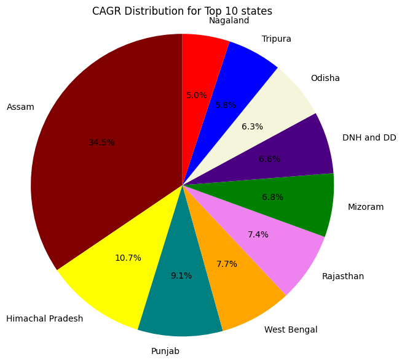

```python
labels=res.index
sizes=res.values

colors1=['maroon','yellow','teal','orange','violet','green','indigo','beige','blue','red']
plt.figure(figsize=(7, 7))
plt.pie(sizes,labels=labels,colors=colors1,autopct='%1.1f%%',startangle=90)

# Equal aspect ratio ensures the pie chart is drawn as a circle.
plt.axis('equal')
plt.title('CAGR Distribution for Top 10 states')
plt.show()
```

```python
#8.What are the peak and low season months for EV sales based on the data from 2022 to 2024?
```

```python
df2
```

|  | date | vehicle_category | maker | electric_vehicles_sold |
| --- | --- | --- | --- | --- |
| 0 | 2021-04-01 | 2-Wheelers | OLA ELECTRIC | 0 |
| 1 | 2022-04-01 | 2-Wheelers | OKAYA EV | 0 |
| 2 | 2021-05-01 | 2-Wheelers | OLA ELECTRIC | 0 |
| 3 | 2021-06-01 | 2-Wheelers | OLA ELECTRIC | 0 |
| 4 | 2021-07-01 | 2-Wheelers | OLA ELECTRIC | 0 |
| ... | ... | ... | ... | ... |
| 811 | 2024-03-01 | 2-Wheelers | BGAUSS | 3070 |
| 812 | 2024-03-01 | 2-Wheelers | BATTRE ELECTRIC | 625 |
| 813 | 2024-03-01 | 2-Wheelers | KINETIC GREEN | 3915 |
| 814 | 2024-03-01 | 2-Wheelers | REVOLT | 585 |
| 815 | 2024-03-01 | 2-Wheelers | OTHERS | 10579 |

816 rows × 4 columns

```python
df2['date'] = pd.to_datetime(df2['date'])
```

```python
# empty dictionary creation to store month and total_ev_sold as key:value pair
month_tot_22 = {}
month_tot_23 = {}
month_tot_24 = {}
```

```python
# totals for each month of 2022
month_tot_22['Apr']=df2[(df2['date']>'2021-03-31') & (df2['date']<'2021-05-01')]['electric_vehicles_sold'].sum()
month_tot_22['May']=df2[(df2['date']>'2021-04-30') & (df2['date']<'2021-06-01')]['electric_vehicles_sold'].sum()
month_tot_22['Jun']=df2[(df2['date']>'2021-05-31') & (df2['date']<'2021-07-01')]['electric_vehicles_sold'].sum()
month_tot_22['Jul']=df2[(df2['date']>'2021-06-30') & (df2['date']<'2021-08-01')]['electric_vehicles_sold'].sum()
month_tot_22['Aug']=df2[(df2['date']>'2021-07-31') & (df2['date']<'2021-09-01')]['electric_vehicles_sold'].sum()
month_tot_22['Sep']=df2[(df2['date']>'2021-08-31') & (df2['date']<'2021-10-01')]['electric_vehicles_sold'].sum()
month_tot_22['Oct']=df2[(df2['date']>'2021-09-30') & (df2['date']<'2021-11-01')]['electric_vehicles_sold'].sum()
month_tot_22['Nov']=df2[(df2['date']>'2021-10-31') & (df2['date']<'2021-12-01')]['electric_vehicles_sold'].sum()
month_tot_22['Dec']=df2[(df2['date']>'2021-11-30') & (df2['date']<'2022-01-01')]['electric_vehicles_sold'].sum()
month_tot_22['Jan']=df2[(df2['date']>'2021-12-31') & (df2['date']<'2022-02-01')]['electric_vehicles_sold'].sum()
month_tot_22['Feb']=df2[(df2['date']>'2022-01-31') & (df2['date']<'2022-03-01')]['electric_vehicles_sold'].sum()
month_tot_22['Mar']=df2[(df2['date']>'2022-02-28') & (df2['date']<'2022-04-01')]['electric_vehicles_sold'].sum()
```

```python
# totals for each month of 2023
month_tot_23['Apr']=df2[(df2['date']>'2022-03-31') & (df2['date']<'2022-05-01')]['electric_vehicles_sold'].sum()
month_tot_23['May']=df2[(df2['date']>'2022-04-30') & (df2['date']<'2022-06-01')]['electric_vehicles_sold'].sum()
month_tot_23['Jun']=df2[(df2['date']>'2022-05-31') & (df2['date']<'2022-07-01')]['electric_vehicles_sold'].sum()
month_tot_23['Jul']=df2[(df2['date']>'2022-06-30') & (df2['date']<'2022-08-01')]['electric_vehicles_sold'].sum()
month_tot_23['Aug']=df2[(df2['date']>'2022-07-31') & (df2['date']<'2022-09-01')]['electric_vehicles_sold'].sum()
month_tot_23['Sep']=df2[(df2['date']>'2022-08-31') & (df2['date']<'2022-10-01')]['electric_vehicles_sold'].sum()
month_tot_23['Oct']=df2[(df2['date']>'2022-09-30') & (df2['date']<'2022-11-01')]['electric_vehicles_sold'].sum()
month_tot_23['Nov']=df2[(df2['date']>'2022-10-31') & (df2['date']<'2022-12-01')]['electric_vehicles_sold'].sum()
month_tot_23['Dec']=df2[(df2['date']>'2022-11-30') & (df2['date']<'2023-01-01')]['electric_vehicles_sold'].sum()
month_tot_23['Jan']=df2[(df2['date']>'2022-12-31') & (df2['date']<'2023-02-01')]['electric_vehicles_sold'].sum()
month_tot_23['Feb']=df2[(df2['date']>'2023-01-31') & (df2['date']<'2023-03-01')]['electric_vehicles_sold'].sum()
month_tot_23['Mar']=df2[(df2['date']>'2023-02-28') & (df2['date']<'2023-04-01')]['electric_vehicles_sold'].sum()
```

```python
# totals for each month of 2024
month_tot_24['Apr']=df2[(df2['date']>'2023-03-31') & (df2['date']<'2023-05-01')]['electric_vehicles_sold'].sum()
month_tot_24['May']=df2[(df2['date']>'2023-04-30') & (df2['date']<'2023-06-01')]['electric_vehicles_sold'].sum()
month_tot_24['Jun']=df2[(df2['date']>'2023-05-31') & (df2['date']<'2023-07-01')]['electric_vehicles_sold'].sum()
month_tot_24['Jul']=df2[(df2['date']>'2023-06-30') & (df2['date']<'2023-08-01')]['electric_vehicles_sold'].sum()
month_tot_24['Aug']=df2[(df2['date']>'2023-07-31') & (df2['date']<'2023-09-01')]['electric_vehicles_sold'].sum()
month_tot_24['Sep']=df2[(df2['date']>'2023-08-31') & (df2['date']<'2023-10-01')]['electric_vehicles_sold'].sum()
month_tot_24['Oct']=df2[(df2['date']>'2023-09-30') & (df2['date']<'2023-11-01')]['electric_vehicles_sold'].sum()
month_tot_24['Nov']=df2[(df2['date']>'2023-10-31') & (df2['date']<'2023-12-01')]['electric_vehicles_sold'].sum()
month_tot_24['Dec']=df2[(df2['date']>'2023-11-30') & (df2['date']<'2024-01-01')]['electric_vehicles_sold'].sum()
month_tot_24['Jan']=df2[(df2['date']>'2023-12-31') & (df2['date']<'2024-02-01')]['electric_vehicles_sold'].sum()
month_tot_24['Feb']=df2[(df2['date']>'2024-01-31') & (df2['date']<'2024-03-01')]['electric_vehicles_sold'].sum()
month_tot_24['Mar']=df2[(df2['date']>'2024-02-29') & (df2['date']<'2024-04-01')]['electric_vehicles_sold'].sum()
```

```python
month_tot_22
```

```
{'Apr': 6315,
 'May': 1499,
 'Jun': 5487,
 'Jul': 15794,
 'Aug': 17153,
 'Sep': 19351,
 'Oct': 22190,
 'Nov': 26159,
 'Dec': 29241,
 'Jan': 31672,
 'Feb': 38171,
 'Mar': 58118}
```

```python
month_tot_23
```

```
{'Apr': 55524,
 'May': 45373,
 'Jun': 47591,
 'Jul': 50010,
 'Aug': 55584,
 'Sep': 56828,
 'Oct': 81162,
 'Nov': 80752,
 'Dec': 68475,
 'Jan': 68116,
 'Feb': 70827,
 'Mar': 95126}
```

```python
month_tot_24
```

```
{'Apr': 72818,
 'May': 112997,
 'Jun': 53631,
 'Jul': 61622,
 'Aug': 69224,
 'Sep': 69793,
 'Oct': 81833,
 'Nov': 98285,
 'Dec': 82685,
 'Jan': 89311,
 'Feb': 89051,
 'Mar': 138343}
```

```python
# inserting values to the empty dictionary
month_tot_22={'Jan': 31672,
 'Feb': 38171,
 'Mar': 58118,
 'Apr': 6315,
 'May': 1499,
 'Jun': 5487,
 'Jul': 15794,
 'Aug': 17153,
 'Sep': 19351,
 'Oct': 22190,
 'Nov': 26159,
 'Dec': 29241}
```

```python
month_tot_23={'Apr': 55524,
 'May': 45373,
 'Jun': 47591,
 'Jul': 50010,
 'Aug': 55584,
 'Sep': 56828,
 'Oct': 81162,
 'Nov': 80752,
 'Dec': 68475,
 'Jan': 68116,
 'Feb': 70827,
 'Mar': 95126}
```

```python
month_tot_24={'Apr': 72818,
 'May': 112997,
 'Jun': 53631,
 'Jul': 61622,
 'Aug': 69224,
 'Sep': 69793,
 'Oct': 81833,
 'Nov': 98285,
 'Dec': 82685,
 'Jan': 89311,
 'Feb': 89051,
 'Mar': 138343}
```

```python
#creating dataframes from dictionary for easy data anlysis
df_2022=pd.DataFrame(list(month_tot_22.items()), columns=['Month', 'Tot_EV_sold'])
df_2023=pd.DataFrame(list(month_tot_23.items()), columns=['Month', 'Tot_EV_sold'])
df_2024=pd.DataFrame(list(month_tot_24.items()), columns=['Month', 'Tot_EV_sold'])
```

```python
# getting all information in one place
merged_df_2022_2023 = pd.merge(df_2022, df_2023, on='Month', how='outer', suffixes=('_2022', '_2023'))
```

```python
merged_df_2022_2023
```

|  | Month | Tot_EV_sold_2022 | Tot_EV_sold_2023 |
| --- | --- | --- | --- |
| 0 | Jan | 31672 | 68116 |
| 1 | Feb | 38171 | 70827 |
| 2 | Mar | 58118 | 95126 |
| 3 | Apr | 6315 | 55524 |
| 4 | May | 1499 | 45373 |
| 5 | Jun | 5487 | 47591 |
| 6 | Jul | 15794 | 50010 |
| 7 | Aug | 17153 | 55584 |
| 8 | Sep | 19351 | 56828 |
| 9 | Oct | 22190 | 81162 |
| 10 | Nov | 26159 | 80752 |
| 11 | Dec | 29241 | 68475 |

```python
final_merged_df = pd.merge(merged_df_2022_2023, df_2024, on='Month', how='outer')
```

```python
final_merged_df
```

|  | Month | Tot_EV_sold_2022 | Tot_EV_sold_2023 | Tot_EV_sold |
| --- | --- | --- | --- | --- |
| 0 | Jan | 31672 | 68116 | 89311 |
| 1 | Feb | 38171 | 70827 | 89051 |
| 2 | Mar | 58118 | 95126 | 138343 |
| 3 | Apr | 6315 | 55524 | 72818 |
| 4 | May | 1499 | 45373 | 112997 |
| 5 | Jun | 5487 | 47591 | 53631 |
| 6 | Jul | 15794 | 50010 | 61622 |
| 7 | Aug | 17153 | 55584 | 69224 |
| 8 | Sep | 19351 | 56828 | 69793 |
| 9 | Oct | 22190 | 81162 | 81833 |
| 10 | Nov | 26159 | 80752 | 98285 |
| 11 | Dec | 29241 | 68475 | 82685 |

```python
final_merged_df
```

|  | Month | Tot_EV_sold_2022 | Tot_EV_sold_2023 | Tot_EV_sold |
| --- | --- | --- | --- | --- |
| 0 | Jan | 31672 | 68116 | 89311 |
| 1 | Feb | 38171 | 70827 | 89051 |
| 2 | Mar | 58118 | 95126 | 138343 |
| 3 | Apr | 6315 | 55524 | 72818 |
| 4 | May | 1499 | 45373 | 112997 |
| 5 | Jun | 5487 | 47591 | 53631 |
| 6 | Jul | 15794 | 50010 | 61622 |
| 7 | Aug | 17153 | 55584 | 69224 |
| 8 | Sep | 19351 | 56828 | 69793 |
| 9 | Oct | 22190 | 81162 | 81833 |
| 10 | Nov | 26159 | 80752 | 98285 |
| 11 | Dec | 29241 | 68475 | 82685 |

```python
month_order = ['Apr','May','Jun','Jul','Aug','Sep','Oct','Nov','Dec','Jan','Feb','Mar']

# After merging, sort based on the custom month order
merged_df['Month'] = pd.Categorical(merged_df['Month'], categories=month_order, ordered=True)
# Sort the dataframe by the Month column
merged_df = merged_df.sort_values('Month')
```

```python
merged_df.rename(columns={'Tot_EV_sold': 'Tot_EV_sold_2024'}, inplace=True)
```

```python
print(merged_df.to_string(index=False))  # dataframe without index  # df.to_csv('output.csv', index=False)
```

```
Month  Tot_EV_sold_2022  Tot_EV_sold_2023  Tot_EV_sold_2024
  Apr              6315             55524             72818
  May              1499             45373            112997
  Jun              5487             47591             53631
  Jul             15794             50010             61622
  Aug             17153             55584             69224
  Sep             19351             56828             69793
  Oct             22190             81162             81833
  Nov             26159             80752             98285
  Dec             29241             68475             82685
  Jan             31672             68116             89311
  Feb             38171             70827             89051
  Mar             58118             95126            138343
```

```python
merged_df.to_csv('output8.csv',index=False)
```

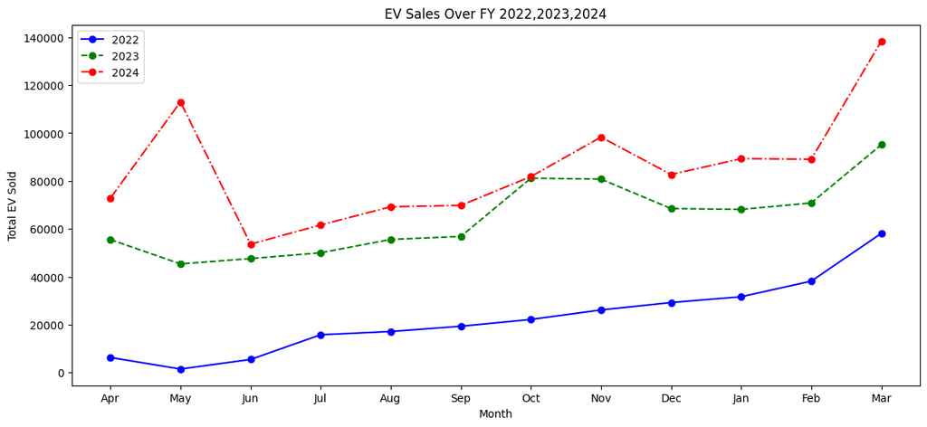

```python
plt.figure(figsize=(14,6))
plt.plot(merged_df['Month'], merged_df['Tot_EV_sold_2022'], label='2022', marker='o', color='blue', linestyle='-')
plt.plot(merged_df['Month'], merged_df['Tot_EV_sold_2023'], label='2023', marker='o', color='green', linestyle='--')
plt.plot(merged_df['Month'], merged_df['Tot_EV_sold_2024'], label='2024', marker='o', color='red', linestyle='-.')
plt.xlabel('Month')
plt.ylabel('Total EV Sold')
plt.title('EV Sales Over FY 2022,2023,2024')
plt.xticks(rotation=0)
plt.legend()
plt.show()
```

Ev sales gradually increasing over years.Only Oct2023 and Oct2024 have nearly same EV sales. {Highest EV sales:Mar2024(138343),lowest EV sales:May2022(1499)}

# 9. What is the projected number of EV sales (including 2-wheelers and 4-wheelers) for the top 10 states by penetration rate in 2030,

based on the compounded annual growth rate (CAGR) from previous years?

Answer approach: first top 10state by penetration rate is determined from df3. Then for 2022 ev_sales for those states are calculated , again same thing done for 2024 Then CAGR_22_24(CAGR for 3 years is calculated using formula, CAGR= (Ending_value/ Beginning_value)**(1/n)-1 where n=no.of years here n=2024-2022=2) Lastly,projected EV sales is calculated using formula, Projected Sales=Ending_value×(1+CAGR)**n where n=2030-2024=6) here, Ending_value=EV_sales_2024 Beginning_value=EV_sales_2022 CAGR=CAGR_22_24 projected EV sales=EV_sales_2030 for top 10 states by penetration

```python
df3
```

|  | date | state | vehicle_category | electric_vehicles_sold | total_vehicles_sold |
| --- | --- | --- | --- | --- | --- |
| 0 | 1-Apr-21 | Sikkim | 2-Wheelers | 0 | 398 |
| 1 | 1-Apr-21 | Sikkim | 4-Wheelers | 0 | 361 |
| 2 | 1-May-21 | Sikkim | 2-Wheelers | 0 | 113 |
| 3 | 1-May-21 | Sikkim | 4-Wheelers | 0 | 98 |
| 4 | 1-Jun-21 | Sikkim | 2-Wheelers | 0 | 229 |
| ... | ... | ... | ... | ... | ... |
| 2440 | 1-Mar-24 | Mizoram | 2-Wheelers | 58 | 1932 |
| 2441 | 1-Mar-24 | DNH and DD | 2-Wheelers | 25 | 780 |
| 2442 | 1-Mar-24 | Manipur | 2-Wheelers | 13 | 1394 |
| 2443 | 1-Mar-24 | Andaman & Nicobar Island | 2-Wheelers | 2 | 447 |
| 2444 | 1-Mar-24 | Nagaland | 2-Wheelers | 2 | 1180 |

2445 rows × 5 columns

```python
k=df3.groupby('state')[['electric_vehicles_sold','total_vehicles_sold']].sum()
```

```python
k['penetration_rate']=100*(k['electric_vehicles_sold']/k['total_vehicles_sold'])
```

```python
top10_state=k.sort_values(by='penetration_rate',ascending=False).reset_index().head(10)
```

```python
top10_state
```

|  | state | electric_vehicles_sold | total_vehicles_sold | penetration_rate |
| --- | --- | --- | --- | --- |
| 0 | Goa | 19684 | 199970 | 9.843477 |
| 1 | Karnataka | 312995 | 3994329 | 7.835984 |
| 2 | Delhi | 107312 | 1588436 | 6.755828 |
| 3 | Kerala | 137060 | 2064677 | 6.638326 |
| 4 | Maharashtra | 396045 | 6101429 | 6.491020 |
| 5 | Odisha | 78267 | 1688794 | 4.634491 |
| 6 | Rajasthan | 150366 | 3307591 | 4.546088 |
| 7 | Gujarat | 181389 | 4125551 | 4.396722 |
| 8 | Tamil Nadu | 200062 | 4652363 | 4.300223 |
| 9 | Chandigarh | 5279 | 130628 | 4.041247 |

```python
type(top10_state)
```

```
pandas.core.frame.DataFrame
```

```python
df3['date'] = pd.to_datetime(df3['date'])
```

```python
df3['date'].min()
```

```
Timestamp('2021-04-01 00:00:00')
```

```python
df3['date'].max()
```

```
Timestamp('2024-03-01 00:00:00')
```

```python
df3_2022=df3[(df3['date']>= '2021-04-01') &  (df3['date']<'2022-04-01')]
df3_2024=df3[(df3['date']>= '2023-04-01') &  (df3['date']<'2024-04-01')]
```

```python
merge_2022= df3_2022.merge(top10_state[['state']], on='state',how='inner')
merge_2024=df3_2024.merge(top10_state[['state']], on='state',how='inner')
```

```python
ev_sales_2022 = merge_2022.groupby('state')['electric_vehicles_sold'].sum()
ev_sales_2024 = merge_2024.groupby('state')['electric_vehicles_sold'].sum()
```

```python
ev_sales_2022=ev_sales_2022.rename("ev_sales_2022")
ev_sales_2024=ev_sales_2024.rename("ev_sales_2024")
```

```python
ev_sales=pd.concat([ev_sales_2022,ev_sales_2024],axis=1)
```

```python
ev_sales
```

| state | ev_sales_2022 | ev_sales_2024 |
| --- | --- | --- |
| Chandigarh | 35 | 41 |
| Delhi | 732 | 706 |
| Goa | 80 | 95 |
| Gujarat | 349 | 373 |
| Karnataka | 576 | 520 |
| Kerala | 892 | 344 |
| Maharashtra | 1460 | 4043 |
| Odisha | 32 | 62 |
| Rajasthan | 175 | 323 |
| Tamil Nadu | 358 | 450 |

```python
ev_sales['CAGR_22_24']=(ev_sales['ev_sales_2024']/ev_sales['ev_sales_2022'])**(1/2)-1
```

```python
ev_sales
```

| state | ev_sales_2022 | ev_sales_2024 | CAGR_22_24 |
| --- | --- | --- | --- |
| Chandigarh | 35 | 41 | 0.082326 |
| Delhi | 732 | 706 | -0.017920 |
| Goa | 80 | 95 | 0.089725 |
| Gujarat | 349 | 373 | 0.033812 |
| Karnataka | 576 | 520 | -0.049854 |
| Kerala | 892 | 344 | -0.378993 |
| Maharashtra | 1460 | 4043 | 0.664085 |
| Odisha | 32 | 62 | 0.391941 |
| Rajasthan | 175 | 323 | 0.358571 |
| Tamil Nadu | 358 | 450 | 0.121153 |

Projected Sales=EV_Sales_2024×(1+CAGR)**n n=2030-2024=6

```python
ev_sales['ev_sales_2030']=ev_sales['ev_sales_2024']*(1+ev_sales['CAGR_22_24'])**6
```

```python
ev_sales.sort_values(by="ev_sales_2030",ascending=False)
```

| state | ev_sales_2022 | ev_sales_2024 | CAGR_22_24 | ev_sales_2030 |
| --- | --- | --- | --- | --- |
| Maharashtra | 1460 | 4043 | 0.664085 | 85853.182358 |
| Rajasthan | 175 | 323 | 0.358571 | 2030.934622 |
| Tamil Nadu | 358 | 450 | 0.121153 | 893.718968 |
| Delhi | 732 | 706 | -0.017920 | 633.410941 |
| Gujarat | 349 | 373 | 0.033812 | 455.364370 |
| Odisha | 32 | 62 | 0.391941 | 450.937988 |
| Karnataka | 576 | 520 | -0.049854 | 382.600844 |
| Goa | 80 | 95 | 0.089725 | 159.083252 |
| Chandigarh | 35 | 41 | 0.082326 | 65.906962 |
| Kerala | 892 | 344 | -0.378993 | 19.730551 |

```python
ev_sales.sort_values(by="ev_sales_2030",ascending=False).to_csv('output9.csv')
```

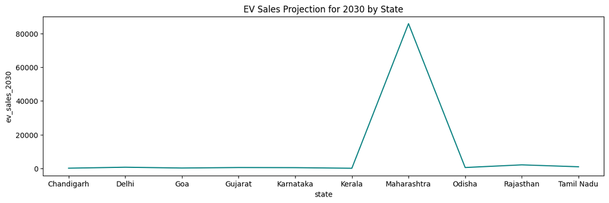

```python
plt.figure(figsize=(14,4))
sns.lineplot(ev_sales,x='state',y='ev_sales_2030',color='teal')
plt.title('EV Sales Projection for 2030 by State')
plt.show()
```

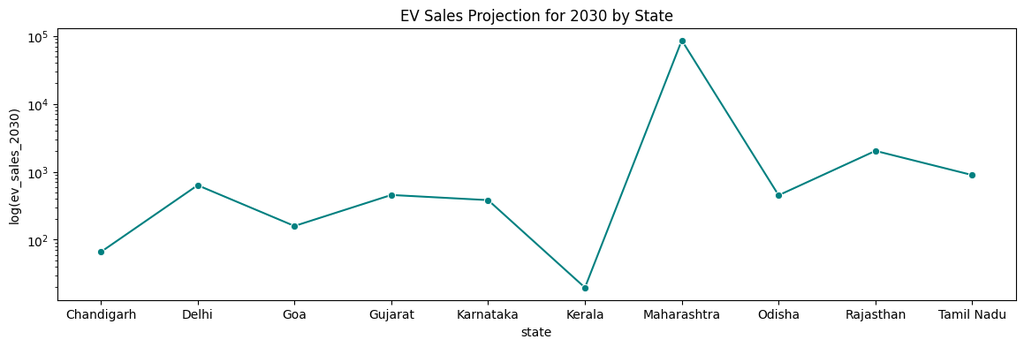

```python
#use log to compress large values and stretch smaller values
plt.figure(figsize=(14,4))
sns.lineplot(ev_sales,x='state',y='ev_sales_2030',color='teal',marker="o")
plt.yscale('log')
plt.ylabel('log(ev_sales_2030)')
plt.title('EV Sales Projection for 2030 by State')
plt.show()
```

```python
#10.Estimate the revenue growth rate of 4-wheeler and 2-wheelers EVs in India for 2022 vs 2024 and 2023 vs 2024, assuming an average unit price.
#Avg unit price for 2_wheelers=85000, 4_wheelers=1500000
```

```python
df3
```

[output not shown]

2445 rows × 5 columns

```python
df3['date'] = pd.to_datetime(df3['date'])
```

```python
df3['date'].min()
```

```
Timestamp('2021-04-01 00:00:00')
```

```python
df3['date'].max()
```

```
Timestamp('2024-03-01 00:00:00')
```

```python
df3_2022= df3[(df3['date']>'2021-03-31') & (df3['date']<'2022-04-01')]
```

```python
df3_2023=df3[(df3['date']>'2022-03-31') & (df3['date']<'2023-04-01')]
```

```python
df3_2024=df3[(df3['date']>'2023-03-31') & (df3['date']<'2024-04-01')]
```

```python
Rev2w_2022 = df3_2022[df3_2022['vehicle_category'] =='2-Wheelers'].groupby('vehicle_category')['electric_vehicles_sold'].sum() * 85000
Rev2w_2023 = df3_2023[df3_2023['vehicle_category'] == '2-Wheelers'].groupby('vehicle_category')['electric_vehicles_sold'].sum() * 85000
Rev2w_2024 = df3_2024[df3_2024['vehicle_category'] == '2-Wheelers'].groupby('vehicle_category')['electric_vehicles_sold'].sum() * 85000
```

```python
Rev4w_2022 = df3_2022[df3_2022['vehicle_category'] == '4-Wheelers'].groupby('vehicle_category')['electric_vehicles_sold'].sum() * 1500000
Rev4w_2023 = df3_2023[df3_2023['vehicle_category'] == '4-Wheelers'].groupby('vehicle_category')['electric_vehicles_sold'].sum() * 1500000
Rev4w_2024 = df3_2024[df3_2024['vehicle_category'] == '4-Wheelers'].groupby('vehicle_category')['electric_vehicles_sold'].sum() * 1500000
```

```python
type(Rev4w_2024)
```

```
pandas.core.series.Series
```

```python
Revenue2w={'Rev_2022':Rev2w_2022,'Rev_2023':Rev2w_2023,'Rev_2024':Rev2w_2024}
```

```python
two_wh=pd.DataFrame(Revenue2w)
```

```python
Revenue4w={'Rev_2022':Rev4w_2022,'Rev_2023':Rev4w_2023,'Rev_2024':Rev4w_2024}
```

```python
four_wh=pd.DataFrame(Revenue4w)
```

```python
x=pd.concat([two_wh,four_wh],join='inner')
```

```python
type(x)
```

```
pandas.core.frame.DataFrame
```

```python
x
```

| vehicle_category | Rev_2022 | Rev_2023 | Rev_2024 |
| --- | --- | --- | --- |
| 2-Wheelers | 765000 | 765000 | 935000 |
| 4-Wheelers | 7983000000 | 8485500000 | 11548500000 |

```python
x['% growth_22_24']=100*(x['Rev_2024']-x['Rev_2022'])/x['Rev_2022']
```

```python
x
```

| vehicle_category | Rev_2022 | Rev_2023 | Rev_2024 | % growth_22_24 |
| --- | --- | --- | --- | --- |
| 2-Wheelers | 765000 | 765000 | 935000 | 22.222222 |
| 4-Wheelers | 7983000000 | 8485500000 | 11548500000 | 44.663660 |

```python
x['% growth_23_24']=100*(x['Rev_2024']-x['Rev_2023'])/x['Rev_2023']
```

```python
x
```

| vehicle_category | Rev_2022 | Rev_2023 | Rev_2024 | % growth_22_24 | % growth_23_24 |
| --- | --- | --- | --- | --- | --- |
| 2-Wheelers | 765000 | 765000 | 935000 | 22.222222 | 22.222222 |
| 4-Wheelers | 7983000000 | 8485500000 | 11548500000 | 44.663660 | 36.096871 |

```python
x.to_csv('output11.csv')
```

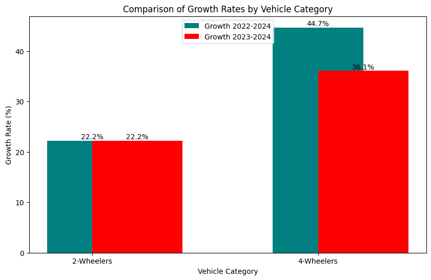

```python
vehicle_category = ['2-Wheelers', '4-Wheelers']
growth_22_24 = [22.22,44.66]
growth_23_24 = [22.22,36.096]
fig, ax = plt.subplots(figsize=(10, 6))

chat1=ax.bar(vehicle_category, growth_22_24, width=0.4, label='Growth 2022-2024', align='center', color='teal')

chat2=ax.bar(vehicle_category, growth_23_24, width=0.4, label='Growth 2023-2024', align='edge', color='red')

for bar in chat1:
    height = bar.get_height()
    ax.text(bar.get_x() + bar.get_width() / 2, height, f'{height:.1f}%', ha='center', va='bottom')

for bar in chat2:
    height = bar.get_height()
    ax.text(bar.get_x() + bar.get_width() / 2, height, f'{height:.1f}%', ha='center', va='bottom')

ax.set_xlabel('Vehicle Category')
ax.set_ylabel('Growth Rate (%)')
ax.set_title('Comparison of Growth Rates by Vehicle Category')
ax.legend(loc='upper center')
plt.show()
```

Secondary Research Questions

```python
#1.What are the primary reasons for customers choosing 4-wheeler EVs in 2023 and 2024 (cost savings, environmental concerns, government incentives)?
```

```python
df3
```

|  | date | state | vehicle_category | electric_vehicles_sold | total_vehicles_sold |
| --- | --- | --- | --- | --- | --- |
| 0 | 1-Apr-21 | Sikkim | 2-Wheelers | 0 | 398 |
| 1 | 1-Apr-21 | Sikkim | 4-Wheelers | 0 | 361 |
| 2 | 1-May-21 | Sikkim | 2-Wheelers | 0 | 113 |
| 3 | 1-May-21 | Sikkim | 4-Wheelers | 0 | 98 |
| 4 | 1-Jun-21 | Sikkim | 2-Wheelers | 0 | 229 |
| ... | ... | ... | ... | ... | ... |
| 2440 | 1-Mar-24 | Mizoram | 2-Wheelers | 58 | 1932 |
| 2441 | 1-Mar-24 | DNH and DD | 2-Wheelers | 25 | 780 |
| 2442 | 1-Mar-24 | Manipur | 2-Wheelers | 13 | 1394 |
| 2443 | 1-Mar-24 | Andaman & Nicobar Island | 2-Wheelers | 2 | 447 |
| 2444 | 1-Mar-24 | Nagaland | 2-Wheelers | 2 | 1180 |

2445 rows × 5 columns

```python
df3['date'] = pd.to_datetime(df3['date'])
```

```python
Ndf3_2023=df3[(df3['date']>'31-03-2022') & (df3['date']<'01-04-2023')]
```

```python
Ndf3_2023
```

|  | date | state | vehicle_category | electric_vehicles_sold | total_vehicles_sold |
| --- | --- | --- | --- | --- | --- |
| 24 | 2022-04-01 | Sikkim | 2-Wheelers | 0 | 455 |
| 25 | 2022-04-01 | Sikkim | 4-Wheelers | 0 | 380 |
| 26 | 2022-05-01 | Sikkim | 2-Wheelers | 0 | 461 |
| 27 | 2022-05-01 | Sikkim | 4-Wheelers | 0 | 421 |
| 28 | 2022-06-01 | Sikkim | 2-Wheelers | 0 | 429 |
| ... | ... | ... | ... | ... | ... |
| 2030 | 2023-01-01 | Tamil Nadu | 2-Wheelers | 5505 | 135769 |
| 2031 | 2023-01-01 | Tripura | 2-Wheelers | 8 | 2766 |
| 2032 | 2023-01-01 | Uttar Pradesh | 2-Wheelers | 1952 | 171721 |
| 2033 | 2023-01-01 | Uttarakhand | 2-Wheelers | 447 | 12862 |
| 2034 | 2023-01-01 | West Bengal | 2-Wheelers | 632 | 52431 |

680 rows × 5 columns

```python
Ndf3_2024=df3[(df3['date']>'31-03-2023') & (df3['date']<'01-04-2024')]
```

```python
Ndf3_2w_2023 = Ndf3_2023[Ndf3_2023['vehicle_category'] == '2-Wheelers'].groupby('vehicle_category')['electric_vehicles_sold'].sum()
Ndf3_2w_2024 = Ndf3_2024[Ndf3_2024['vehicle_category'] == '2-Wheelers'].groupby('vehicle_category')['electric_vehicles_sold'].sum()
Ndf3_4w_2023 = Ndf3_2023[Ndf3_2023['vehicle_category'] == '4-Wheelers'].groupby('vehicle_category')['electric_vehicles_sold'].sum()
Ndf3_4w_2024 = Ndf3_2024[Ndf3_2024['vehicle_category'] == '4-Wheelers'].groupby('vehicle_category')['electric_vehicles_sold'].sum()
```

```python
Nx2wh={'Ndf3_2023':Ndf3_2w_2023,'Ndf3_2024':Ndf3_2w_2024}
Nx2wh=pd.DataFrame(Nx2wh)
```

```python
Nx4wh={'Ndf3_2023':Ndf3_4w_2023,'Ndf3_2024':Ndf3_4w_2024}
Nx4wh=pd.DataFrame(Nx4wh)
```

```python
Nx=pd.concat([Nx2wh,Nx4wh],join='inner')
```

```python
Nx
```

| vehicle_category | Ndf3_2023 | Ndf3_2024 |
| --- | --- | --- |
| 2-Wheelers | 575526 | 721124 |
| 4-Wheelers | 33889 | 71075 |

```python
Nx.to_csv('output1.csv')
```

clearly customer are chosing more 2_wheeler EVs in 2023 and 2024 as compared to 4_wheeler Evs. https://e-amrit.niti.gov.in/ Lower running cost Lower maintianance cost Zero tailpipe emissions No noise polllution Ease of charging at home Tax and Financial benefits: FAME II benefits plus additional state wise incentives (Purchase Incentives: Direct discount provided to the user on the cost of the electric vehicle Coupons: Financial incentive where the amount is reimbursed later Interest Subventions:Discount offered on the interest rate while availing loan Road tax exemption:Road tax at the time of purchase is waived off Registration fee exemption:One-time registration fee applicable on new vehicle purchase is waived off Income tax benefit: Provided as a deduction on the tax amount payable by an individual to the government Scrapping incentives:Provided upon de-registering old Petrol and Diesel Vehicles Others: Incentives such as interest-free loans, top-up subsidies, special incentives on electric three-wheelers, etc. can also be availed)

```python
#2.How do government incentives and subsidies impact the adoption rates of 2-wheelers and 4-wheelers? Which states in India provided most subsidies?
```

Information collected from "www.tatacapital.com" and "www.godigit.com" Features of Phase II of FAME( “Faster Adoption and Manufacturing of Electric and Hybrid Vehicles in India”) India Scheme:- FAME phase II valid till 31st Mar 2024 The second phase of Fame India Scheme stresses on electrification of public transportation and shared transportation. This phase gets budgetary support of ₹ 10,000 crores. Through this scheme, the concerned department aims to provide incentives to various categories of vehicles. These are- Electric Two-wheelers: 10 lakh registered electric two-wheelers will get an incentive of ₹ 20,000 each. Electric Four-wheelers: 35,000 electric 4-wheelers with ex-factory price of ₹ 15 lakh will get an incentive of ₹ 1.5 lakh each. Hybrid Four-wheelers: Through this scheme, the Government will provide ₹ 13,000 - ₹ 20,000 as an incentive to hybrid 4-wheelers with ex-factory price of ₹ 15 lakh. e-rickshaws: 5 lakh e-rickshaws (each) can avail ₹ 50,000 as incentives. e-buses: Nearly 8000 e-buses with a maximum ex-factory price of ₹ 2 crores will receive an incentive of ₹ 50 lakh each. Under the second phase of Fame India Scheme, the Government is hopeful of establishing 2700 charging stations in metros, smart cities, hilly states, million-plus cities across the country. The grid measurement will follow a 3 km x 3 km layout. The Government aims to cover highways as well and establish charging stations on both sides of the road with a gap of 25 km between two consecutive stations. Top EV-friendly States that Offer Best Incentives to Buyers: As every Indian state frames its EV policy in alignment with the FAME subsidy scheme, the incentive or electric car subsidy will vary from state to state. Here are a few states that offer the best EV subsidy to buyers- 1>Gujarat: Two-wheeler: Maximum up to Rs. 20,000 Three-wheeler: Benefits up to Rs. 50,000 Four-wheeler: Maximum up to Rs. 1.5 lakh 2>Maharashtra Two-wheeler: Maximum up to Rs. 25,000 Three-wheeler: Benefits up to Rs. 30,000 Four-wheeler: Maximum up to Rs. 2.5 lakh 3>Meghalaya Two-wheeler: Maximum up to Rs. 20,000 Three-wheeler: NA Four-wheeler: Maximum up to Rs. 60,000 4>Karnataka Besides the FAME EV subsidy, Karnataka doesn’t extend any direct incentives to EV buyers. But it gives electric car subsidy to EV makers. 5>Andhra Pradesh Andhra Pradesh also doesn’t directly offer electric car subsidy to buyers but it offers them an exemption from registration charges and road tax. 6>Telangana Telangana offers EV buyers complete exemption from registration charges and road tax besides the FAME incentive. 7>Tamil Nadu Tamil Nadu offers a 100% road tax waiver and zero registration charges for EV buyers. However, the state government is looking to reconsider its EV policy. 8>Kerala EV buyers in Kerala can get a 50% discount on road tax for the first five years. The state also gives a subsidy to e-rickshaws ranging from 10,000 to 30,000.

```python
#Let's find out the impact of subsidies for two best states:Gujarat and Maharastra (these two state govt provide best subsidy) for FY2024
df3['date'] = pd.to_datetime(df3['date'])
df3_2024=df3[(df3['date']>'31-03-2023') & (df3['date']<'01-04-2024')]
```

```python
df3_2024['date'] = pd.to_datetime(df3_2024['date'])
```

```python
df3_2024['month'] = df3_2024['date'].dt.strftime('%b')   # getting abbreviated month names
```

```python
G=df3_2024[df3_2024['state']=='Gujarat']
```

```python
G
```

|  | date | state | vehicle_category | electric_vehicles_sold | total_vehicles_sold | month |
| --- | --- | --- | --- | --- | --- | --- |
| 1118 | 2023-04-01 | Gujarat | 4-Wheelers | 537 | 28451 | Apr |
| 1144 | 2023-05-01 | Gujarat | 4-Wheelers | 710 | 25770 | May |
| 1171 | 2023-06-01 | Gujarat | 4-Wheelers | 698 | 24829 | Jun |
| 1200 | 2023-07-01 | Gujarat | 4-Wheelers | 692 | 27755 | Jul |
| 1229 | 2023-08-01 | Gujarat | 4-Wheelers | 512 | 25572 | Aug |
| 1258 | 2023-09-01 | Gujarat | 4-Wheelers | 633 | 36818 | Sep |
| 1286 | 2023-10-01 | Gujarat | 4-Wheelers | 670 | 42365 | Oct |
| 1314 | 2023-11-01 | Gujarat | 4-Wheelers | 592 | 32601 | Nov |
| 1344 | 2023-12-01 | Gujarat | 4-Wheelers | 548 | 26023 | Dec |
| 1372 | 2024-01-01 | Gujarat | 4-Wheelers | 494 | 33379 | Jan |
| 2100 | 2023-04-01 | Gujarat | 2-Wheelers | 8266 | 89782 | Apr |
| 2129 | 2023-05-01 | Gujarat | 2-Wheelers | 9609 | 87169 | May |
| 2159 | 2023-06-01 | Gujarat | 2-Wheelers | 4019 | 80898 | Jun |
| 2188 | 2023-07-01 | Gujarat | 2-Wheelers | 5300 | 98394 | Jul |
| 2217 | 2023-08-01 | Gujarat | 2-Wheelers | 5755 | 87134 | Aug |
| 2246 | 2023-09-01 | Gujarat | 2-Wheelers | 7209 | 129851 | Sep |
| 2274 | 2023-10-01 | Gujarat | 2-Wheelers | 8417 | 149414 | Oct |
| 2303 | 2023-11-01 | Gujarat | 2-Wheelers | 5424 | 152556 | Nov |
| 2334 | 2023-12-01 | Gujarat | 2-Wheelers | 4080 | 85848 | Dec |
| 2363 | 2024-01-01 | Gujarat | 2-Wheelers | 5424 | 91933 | Jan |

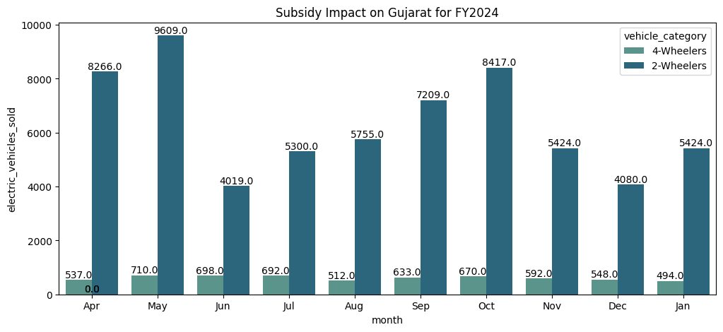

```python
plt.figure(figsize=(12,5))
ax=sns.barplot(x='month',y='electric_vehicles_sold',data=G,hue='vehicle_category',palette='crest')
for bar in ax.patches:
    ax.text(
        bar.get_x() + bar.get_width() / 2,  # X coordinate (center of the bar)
        bar.get_height(),                   # Y coordinate (height of the bar)
        '{:.1f}'.format(bar.get_height()),         # Label text (formatted value)
        ha='center', va='bottom'            # Align the text in the center horizontally and above the bar vertically
    )
plt.title('Subsidy Impact on Gujarat for FY2024')
plt.show()
```

From Jun2023 to oct 2023 sales have constantly increased for two wheelers FAME II subsidy is extended till 31st July 2024. So,we can expect more sales in upcoming months.

```python
df3['date'] = pd.to_datetime(df3['date'])
df3_2024=df3[(df3['date']>'31-03-2023') & (df3['date']<'01-04-2024')]
```

```python
df3_2024['date'] = pd.to_datetime(df3_2024['date'])
```

```python
df3_2024['month'] = df3_2024['date'].dt.strftime('%b')
```

```python
M=df3_2024[df3_2024['state']=='Maharashtra']
```

```python
M
```

|  | date | state | vehicle_category | electric_vehicles_sold | total_vehicles_sold | month |
| --- | --- | --- | --- | --- | --- | --- |
| 1126 | 2023-04-01 | Maharashtra | 4-Wheelers | 1139 | 35336 | Apr |
| 1152 | 2023-05-01 | Maharashtra | 4-Wheelers | 1137 | 35179 | May |
| 1179 | 2023-06-01 | Maharashtra | 4-Wheelers | 1360 | 36069 | Jun |
| 1208 | 2023-07-01 | Maharashtra | 4-Wheelers | 1103 | 36082 | Jul |
| 1237 | 2023-08-01 | Maharashtra | 4-Wheelers | 1070 | 40169 | Aug |
| 1266 | 2023-09-01 | Maharashtra | 4-Wheelers | 869 | 43063 | Sep |
| 1294 | 2023-10-01 | Maharashtra | 4-Wheelers | 1404 | 47126 | Oct |
| 1322 | 2023-11-01 | Maharashtra | 4-Wheelers | 1315 | 48131 | Nov |
| 1352 | 2023-12-01 | Maharashtra | 4-Wheelers | 1125 | 32212 | Dec |
| 1364 | 2024-01-01 | Maharashtra | 4-Wheelers | 1289 | 50156 | Jan |
| 2108 | 2023-04-01 | Maharashtra | 2-Wheelers | 12260 | 130977 | Apr |
| 2138 | 2023-05-01 | Maharashtra | 2-Wheelers | 20585 | 126680 | May |
| 2168 | 2023-06-01 | Maharashtra | 2-Wheelers | 8451 | 119809 | Jun |
| 2196 | 2023-07-01 | Maharashtra | 2-Wheelers | 9822 | 126943 | Jul |
| 2225 | 2023-08-01 | Maharashtra | 2-Wheelers | 12043 | 133378 | Aug |
| 2254 | 2023-09-01 | Maharashtra | 2-Wheelers | 12444 | 134556 | Sep |
| 2282 | 2023-10-01 | Maharashtra | 2-Wheelers | 15716 | 167065 | Oct |
| 2311 | 2023-11-01 | Maharashtra | 2-Wheelers | 19008 | 230768 | Nov |
| 2342 | 2023-12-01 | Maharashtra | 2-Wheelers | 14495 | 174125 | Dec |
| 2355 | 2024-01-01 | Maharashtra | 2-Wheelers | 16367 | 172830 | Jan |

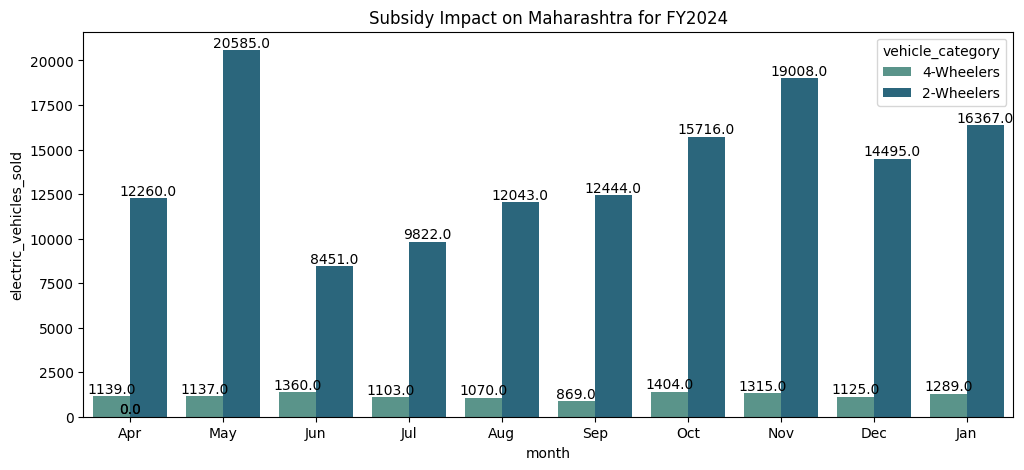

```python
plt.figure(figsize=(12,5))
ax=sns.barplot(x='month',y='electric_vehicles_sold',data=M,hue='vehicle_category',palette='crest')
for bar in ax.patches:
    ax.text(
        bar.get_x() + bar.get_width() / 2,  # X coordinate (center of the bar)
        bar.get_height(),                   # Y coordinate (height of the bar)
        '{:.1f}'.format(bar.get_height()),         # Label text (formatted value)
        ha='center', va='bottom'            # Align the text in the center horizontally and above the bar vertically
    )
    plt.title('Subsidy Impact on Maharashtra for FY2024')
plt.show()
```

From Jun2023 to Nov 2023 2_wheelers sales wer growing. 4_wheelers sale is stagnant for Maharastra also. FAME II subsidy is extended till 31st July 2024. So,we can expect more sales in upcoming months.

```python
#3.How does the availability of charging stations infrastructure correlate with the EV sales and penetration rates in the top 5 states?
```

data imported from https://www.data.gov.in/ [PCS= Public_EV_Charging_Stations] [Data collected till 31st mar2024]

```python
df4=pd.read_csv(r"C:\Users\adian\Downloads\study\python\EV project\datasets\PCS_31Mar2024.csv")
```

```python
df4.head()
```

|  | state | No. of PCS |
| --- | --- | --- |
| 0 | Andaman & Nicobar Island | 3 |
| 1 | Andhra Pradesh | 327 |
| 2 | Arunachal Pradesh | 9 |
| 3 | Assam | 86 |
| 4 | Bihar | 124 |

```python
df4.head().to_csv('outputdf4.csv')
```

```python
df=df3.groupby('state')[['electric_vehicles_sold','total_vehicles_sold']].sum()
```

```python
df
```

| state | electric_vehicles_sold | total_vehicles_sold |
| --- | --- | --- |
| Andaman & Nicobar Island | 80 | 18885 |
| Andhra Pradesh | 77422 | 2283871 |
| Arunachal Pradesh | 33 | 71547 |
| Assam | 6418 | 1403271 |
| Bihar | 31019 | 3048373 |
| Chandigarh | 5279 | 130628 |
| Chhattisgarh | 53804 | 1334989 |
| DNH and DD | 355 | 43397 |
| Delhi | 107312 | 1588436 |
| Goa | 19684 | 199970 |
| Gujarat | 181389 | 4125551 |
| Haryana | 30797 | 1902768 |
| Himachal Pradesh | 2595 | 325366 |
| Jammu and Kashmir | 5971 | 414553 |
| Jharkhand | 18461 | 1364886 |
| Karnataka | 312995 | 3994329 |
| Kerala | 137060 | 2064677 |
| Ladakh | 68 | 10496 |
| Madhya Pradesh | 78979 | 3498698 |
| Maharashtra | 396045 | 6101429 |
| Manipur | 299 | 104513 |
| Meghalaya | 177 | 90183 |
| Mizoram | 340 | 71307 |
| Nagaland | 13 | 44092 |
| Odisha | 78267 | 1688794 |
| Puducherry | 5536 | 150798 |
| Punjab | 23833 | 1543962 |
| Rajasthan | 150366 | 3307591 |
| Sikkim | 0 | 29346 |
| Tamil Nadu | 200062 | 4652363 |
| Tripura | 562 | 125216 |
| Uttar Pradesh | 95203 | 8127084 |
| Uttarakhand | 15127 | 622707 |
| West Bengal | 30560 | 2736176 |

```python
df['penetration_rate']=(df['electric_vehicles_sold']/df['total_vehicles_sold'])*100
```

```python
df
```

| state | electric_vehicles_sold | total_vehicles_sold | penetration_rate |
| --- | --- | --- | --- |
| Andaman & Nicobar Island | 80 | 18885 | 0.423617 |
| Andhra Pradesh | 77422 | 2283871 | 3.389946 |
| Arunachal Pradesh | 33 | 71547 | 0.046124 |
| Assam | 6418 | 1403271 | 0.457360 |
| Bihar | 31019 | 3048373 | 1.017559 |
| Chandigarh | 5279 | 130628 | 4.041247 |
| Chhattisgarh | 53804 | 1334989 | 4.030295 |
| DNH and DD | 355 | 43397 | 0.818029 |
| Delhi | 107312 | 1588436 | 6.755828 |
| Goa | 19684 | 199970 | 9.843477 |
| Gujarat | 181389 | 4125551 | 4.396722 |
| Haryana | 30797 | 1902768 | 1.618537 |
| Himachal Pradesh | 2595 | 325366 | 0.797563 |
| Jammu and Kashmir | 5971 | 414553 | 1.440347 |
| Jharkhand | 18461 | 1364886 | 1.352567 |
| Karnataka | 312995 | 3994329 | 7.835984 |
| Kerala | 137060 | 2064677 | 6.638326 |
| Ladakh | 68 | 10496 | 0.647866 |
| Madhya Pradesh | 78979 | 3498698 | 2.257383 |
| Maharashtra | 396045 | 6101429 | 6.491020 |
| Manipur | 299 | 104513 | 0.286089 |
| Meghalaya | 177 | 90183 | 0.196268 |
| Mizoram | 340 | 71307 | 0.476812 |
| Nagaland | 13 | 44092 | 0.029484 |
| Odisha | 78267 | 1688794 | 4.634491 |
| Puducherry | 5536 | 150798 | 3.671136 |
| Punjab | 23833 | 1543962 | 1.543626 |
| Rajasthan | 150366 | 3307591 | 4.546088 |
| Sikkim | 0 | 29346 | 0.000000 |
| Tamil Nadu | 200062 | 4652363 | 4.300223 |
| Tripura | 562 | 125216 | 0.448824 |
| Uttar Pradesh | 95203 | 8127084 | 1.171429 |
| Uttarakhand | 15127 | 622707 | 2.429232 |
| West Bengal | 30560 | 2736176 | 1.116887 |

```python
x=pd.merge(df4,df,on='state',how='inner').sort_values(by='electric_vehicles_sold',ascending=False).reset_index(drop=True)
```

```python
x.drop(columns='total_vehicles_sold', inplace=True)
```

```python
x
```

|  | state | No. of PCS | electric_vehicles_sold | penetration_rate |
| --- | --- | --- | --- | --- |
| 0 | Maharashtra | 3083 | 396045 | 6.491020 |
| 1 | Karnataka | 5130 | 312995 | 7.835984 |
| 2 | Tamil Nadu | 643 | 200062 | 4.300223 |
| 3 | Gujarat | 476 | 181389 | 4.396722 |
| 4 | Rajasthan | 500 | 150366 | 4.546088 |
| 5 | Kerala | 958 | 137060 | 6.638326 |
| 6 | Delhi | 1886 | 107312 | 6.755828 |
| 7 | Uttar Pradesh | 583 | 95203 | 1.171429 |
| 8 | Madhya Pradesh | 341 | 78979 | 2.257383 |
| 9 | Odisha | 198 | 78267 | 4.634491 |
| 10 | Andhra Pradesh | 327 | 77422 | 3.389946 |
| 11 | Chhattisgarh | 149 | 53804 | 4.030295 |
| 12 | Bihar | 124 | 31019 | 1.017559 |
| 13 | Haryana | 377 | 30797 | 1.618537 |
| 14 | West Bengal | 318 | 30560 | 1.116887 |
| 15 | Punjab | 158 | 23833 | 1.543626 |
| 16 | Goa | 113 | 19684 | 9.843477 |
| 17 | Jharkhand | 135 | 18461 | 1.352567 |
| 18 | Uttarakhand | 76 | 15127 | 2.429232 |
| 19 | Assam | 86 | 6418 | 0.457360 |
| 20 | Jammu and Kashmir | 47 | 5971 | 1.440347 |
| 21 | Puducherry | 23 | 5536 | 3.671136 |
| 22 | Chandigarh | 12 | 5279 | 4.041247 |
| 23 | Himachal Pradesh | 44 | 2595 | 0.797563 |
| 24 | Tripura | 18 | 562 | 0.448824 |
| 25 | DNH and DD | 1 | 355 | 0.818029 |
| 26 | Mizoram | 0 | 340 | 0.476812 |
| 27 | Manipur | 17 | 299 | 0.286089 |
| 28 | Meghalaya | 21 | 177 | 0.196268 |
| 29 | Andaman & Nicobar Island | 3 | 80 | 0.423617 |
| 30 | Ladakh | 0 | 68 | 0.647866 |
| 31 | Arunachal Pradesh | 9 | 33 | 0.046124 |
| 32 | Nagaland | 6 | 13 | 0.029484 |
| 33 | Sikkim | 2 | 0 | 0.000000 |

```python
x.to_csv('output12.csv',index=False)
```

```python
x.columns
```

```
Index(['state', 'No. of PCS ', 'electric_vehicles_sold', 'penetration_rate'], dtype='object')
```

```python
corr_matrix = x[['No. of PCS ','penetration_rate','electric_vehicles_sold']].corr()
```

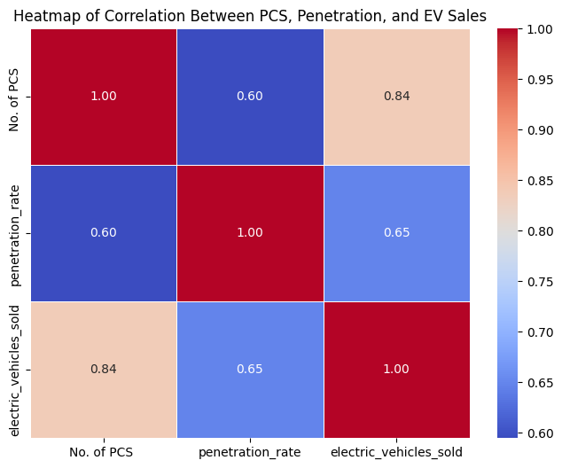

```python
plt.figure(figsize=(8, 6))
sns.heatmap(corr_matrix, annot=True, cmap='coolwarm', linewidths=0.5, fmt=".2f")
plt.title('Heatmap of Correlation Between PCS, Penetration, and EV Sales')
plt.show()
```

```python
#4.Who should be the brand ambassador if AtliQ Motors launches their EV/Hybrid vehicles in India and why?
```

Atliq Motor has the option to hire one of two youth icons, both renowned for their impressive bike collections: MS Dhoni and John Abraham. However, if the goal is to minimize costs while still associating with a prominent figure, they can consider hiring Neeraj Chopra, a celebrated personality admired by Indians across the nation.

```python
#5.Which state of India is ideal to start the manufacturing unit? (Based on subsidies provided, ease of doing business, stability in governance etc.)
```

Maharashtra, Karnataka,Tamil Nadu, Gujarat have better EV penetration and sales than other states (based on datasets) Information collected from Internet: Based on subsidies: Gujarat,Maharastra Based on Ease of doing business:Gujarat, Tamilnadu Based on political stability: Gujarat Based on Lithium reserve: Jharkhand,Rajasthan, Tamilnadu Based on OEM presence: Maharastra, Haryana, Gujarat Connecting port: Gujarat(Mundra), Maharastra(JNPT) Skilled Manpower: Maharastra, Tamilnadu,Haryana,Gujarat EV customer base: Maharastra Infrastructure and market for growth: Gujarat so, I will recommend Gujarat

```python
#6.Your top 3 recommendations for AtliQ Motors.
```

1>Create manufacturing unit in Gujarat nearby Mundra port 2>Procure Lithium from Nagaur district of Rajasthan 3>Transport Electric vehicles to Navi Mumbai JNPT port from Mundra port and use Maharastra's connectivity and largest customer base. Also use Customer demand of Rajasthan,Karnataka,Tamilnadu. Try to maximise the impact of Gujarat's infrastructure and market. 4> Create a research unit in Gujarat for alternative fuels like hydrogen or Aluminium. 5>Initially, Atliq Motors can introduce and attract Indian customers by launching its premium EV products, which are best sellers in North America. However, it is crucial to consider the purchasing power of Indian consumers and the pricing strategies of competitors to ensure market fit.